# Project: Identify Customer Segments

In this project, I will apply unsupervised learning techniques to identify segments of the population that form the core customer base for a mail-order sales company in Germany. These segments can then be used to direct marketing campaigns towards audiences that will have the highest expected rate of returns. The data that you will use has been provided by our partners at Bertelsmann Arvato Analytics, and represents a real-life data science task.

```python
import numpy as np
import pandas as pd
import time
import matplotlib.pyplot as plt
import seaborn as sns
from sklearn import preprocessing as p
from sklearn.decomposition import PCA
from sklearn.cluster import KMeans

from mpl_toolkits.mplot3d import Axes3D



%matplotlib inline
```

### Step 0: Load the Data

Each row of the demographics files represents a single person, but also includes information outside of individuals, including information about their household, building, and neighborhood. You will use this information to cluster the general population into groups with similar demographic properties. Then, you will see how the people in the customers dataset fit into those created clusters. The hope here is that certain clusters are over-represented in the customers data, as compared to the general population; those over-represented clusters will be assumed to be part of the core userbase. This information can then be used for further applications, such as targeting for a marketing campaign.

```python
azdias =  pd.read_csv('Udacity_AZDIAS_Subset.csv',sep=';')
feat_info = pd.read_csv('AZDIAS_Feature_Summary.csv', sep =';')
customers = pd.read_csv('Udacity_CUSTOMERS_Subset.csv', sep=';')
```

```python
# Creating copies of the data to play with
azdias_c = azdias.copy()
feat_info_c = feat_info.copy()
customers_c = customers.copy()
```

```python
df_clean = pd.read_csv('df_clean.csv')
```

### Exploring the data

```python
azdias.sample(3)
```

|  | AGER_TYP | ALTERSKATEGORIE_GROB | ANREDE_KZ | CJT_GESAMTTYP | FINANZ_MINIMALIST | FINANZ_SPARER | FINANZ_VORSORGER | FINANZ_ANLEGER | FINANZ_UNAUFFAELLIGER | FINANZ_HAUSBAUER | ... | PLZ8_ANTG1 | PLZ8_ANTG2 | PLZ8_ANTG3 | PLZ8_ANTG4 | PLZ8_BAUMAX | PLZ8_HHZ | PLZ8_GBZ | ARBEIT | ORTSGR_KLS9 | RELAT_AB |
| --- | --- | --- | --- | --- | --- | --- | --- | --- | --- | --- | --- | --- | --- | --- | --- | --- | --- | --- | --- | --- | --- |
| 728398 | 2 | 4 | 2 | 3.0 | 3 | 1 | 5 | 1 | 2 | 5 | ... | 3.0 | 3.0 | 2.0 | 1.0 | 1.0 | 3.0 | 3.0 | 2.0 | 6.0 | 3.0 |
| 875687 | -1 | 3 | 2 | 6.0 | 3 | 2 | 4 | 4 | 2 | 1 | ... | 4.0 | 2.0 | 0.0 | 0.0 | 1.0 | 5.0 | 5.0 | 2.0 | 3.0 | 1.0 |
| 419410 | -1 | 3 | 2 | 6.0 | 1 | 4 | 1 | 3 | 5 | 5 | ... | 1.0 | 4.0 | 2.0 | 1.0 | 5.0 | 5.0 | 4.0 | 2.0 | 5.0 | 3.0 |

3 rows × 85 columns

```python
azdias.shape
```

```
(891221, 85)
```

```python
azdias.info()
```

```
<class 'pandas.core.frame.DataFrame'>
RangeIndex: 891221 entries, 0 to 891220
Data columns (total 85 columns):
AGER_TYP                 891221 non-null int64
ALTERSKATEGORIE_GROB     891221 non-null int64
ANREDE_KZ                891221 non-null int64
CJT_GESAMTTYP            886367 non-null float64
FINANZ_MINIMALIST        891221 non-null int64
FINANZ_SPARER            891221 non-null int64
FINANZ_VORSORGER         891221 non-null int64
FINANZ_ANLEGER           891221 non-null int64
FINANZ_UNAUFFAELLIGER    891221 non-null int64
FINANZ_HAUSBAUER         891221 non-null int64
FINANZTYP                891221 non-null int64
GEBURTSJAHR              891221 non-null int64
GFK_URLAUBERTYP          886367 non-null float64
GREEN_AVANTGARDE         891221 non-null int64
HEALTH_TYP               891221 non-null int64
LP_LEBENSPHASE_FEIN      886367 non-null float64
LP_LEBENSPHASE_GROB      886367 non-null float64
LP_FAMILIE_FEIN          886367 non-null float64
LP_FAMILIE_GROB          886367 non-null float64
LP_STATUS_FEIN           886367 non-null float64
LP_STATUS_GROB           886367 non-null float64
NATIONALITAET_KZ         891221 non-null int64
PRAEGENDE_JUGENDJAHRE    891221 non-null int64
RETOURTYP_BK_S           886367 non-null float64
SEMIO_SOZ                891221 non-null int64
SEMIO_FAM                891221 non-null int64
SEMIO_REL                891221 non-null int64
SEMIO_MAT                891221 non-null int64
SEMIO_VERT               891221 non-null int64
SEMIO_LUST               891221 non-null int64
SEMIO_ERL                891221 non-null int64
SEMIO_KULT               891221 non-null int64
SEMIO_RAT                891221 non-null int64
SEMIO_KRIT               891221 non-null int64
SEMIO_DOM                891221 non-null int64
SEMIO_KAEM               891221 non-null int64
SEMIO_PFLICHT            891221 non-null int64
```

[output cut: 35 more lines]

```
ONLINE_AFFINITAET        886367 non-null float64
REGIOTYP                 770025 non-null float64
KBA13_ANZAHL_PKW         785421 non-null float64
PLZ8_ANTG1               774706 non-null float64
PLZ8_ANTG2               774706 non-null float64
PLZ8_ANTG3               774706 non-null float64
PLZ8_ANTG4               774706 non-null float64
PLZ8_BAUMAX              774706 non-null float64
PLZ8_HHZ                 774706 non-null float64
PLZ8_GBZ                 774706 non-null float64
ARBEIT                   794005 non-null float64
ORTSGR_KLS9              794005 non-null float64
RELAT_AB                 794005 non-null float64
dtypes: float64(49), int64(32), object(4)
memory usage: 578.0+ MB
```

```python
azdias.describe()
```

|  | AGER_TYP | ALTERSKATEGORIE_GROB | ANREDE_KZ | CJT_GESAMTTYP | FINANZ_MINIMALIST | FINANZ_SPARER | FINANZ_VORSORGER | FINANZ_ANLEGER | FINANZ_UNAUFFAELLIGER | FINANZ_HAUSBAUER | ... | PLZ8_ANTG1 | PLZ8_ANTG2 | PLZ8_ANTG3 | PLZ8_ANTG4 | PLZ8_BAUMAX | PLZ8_HHZ | PLZ8_GBZ | ARBEIT | ORTSGR_KLS9 | RELAT_AB |
| --- | --- | --- | --- | --- | --- | --- | --- | --- | --- | --- | --- | --- | --- | --- | --- | --- | --- | --- | --- | --- | --- |
| count | 891221.000000 | 891221.000000 | 891221.000000 | 886367.000000 | 891221.000000 | 891221.000000 | 891221.000000 | 891221.000000 | 891221.000000 | 891221.000000 | ... | 774706.000000 | 774706.000000 | 774706.000000 | 774706.000000 | 774706.000000 | 774706.000000 | 774706.000000 | 794005.000000 | 794005.000000 | 794005.00000 |
| mean | -0.358435 | 2.777398 | 1.522098 | 3.632838 | 3.074528 | 2.821039 | 3.401106 | 3.033328 | 2.874167 | 3.075121 | ... | 2.253330 | 2.801858 | 1.595426 | 0.699166 | 1.943913 | 3.612821 | 3.381087 | 3.167854 | 5.293002 | 3.07222 |
| std | 1.198724 | 1.068775 | 0.499512 | 1.595021 | 1.321055 | 1.464749 | 1.322134 | 1.529603 | 1.486731 | 1.353248 | ... | 0.972008 | 0.920309 | 0.986736 | 0.727137 | 1.459654 | 0.973967 | 1.111598 | 1.002376 | 2.303739 | 1.36298 |
| min | -1.000000 | 1.000000 | 1.000000 | 1.000000 | 1.000000 | 1.000000 | 1.000000 | 1.000000 | 1.000000 | 1.000000 | ... | 0.000000 | 0.000000 | 0.000000 | 0.000000 | 1.000000 | 1.000000 | 1.000000 | 1.000000 | 0.000000 | 1.00000 |
| 25% | -1.000000 | 2.000000 | 1.000000 | 2.000000 | 2.000000 | 1.000000 | 3.000000 | 2.000000 | 2.000000 | 2.000000 | ... | 1.000000 | 2.000000 | 1.000000 | 0.000000 | 1.000000 | 3.000000 | 3.000000 | 3.000000 | 4.000000 | 2.00000 |
| 50% | -1.000000 | 3.000000 | 2.000000 | 4.000000 | 3.000000 | 3.000000 | 3.000000 | 3.000000 | 3.000000 | 3.000000 | ... | 2.000000 | 3.000000 | 2.000000 | 1.000000 | 1.000000 | 4.000000 | 3.000000 | 3.000000 | 5.000000 | 3.00000 |
| 75% | -1.000000 | 4.000000 | 2.000000 | 5.000000 | 4.000000 | 4.000000 | 5.000000 | 5.000000 | 4.000000 | 4.000000 | ... | 3.000000 | 3.000000 | 2.000000 | 1.000000 | 3.000000 | 4.000000 | 4.000000 | 4.000000 | 7.000000 | 4.00000 |
| max | 3.000000 | 9.000000 | 2.000000 | 6.000000 | 5.000000 | 5.000000 | 5.000000 | 5.000000 | 5.000000 | 5.000000 | ... | 4.000000 | 4.000000 | 3.000000 | 2.000000 | 5.000000 | 5.000000 | 5.000000 | 9.000000 | 9.000000 | 9.00000 |

8 rows × 81 columns

```python
feat_info[:3]
```

|  | attribute | information_level | type | missing_or_unknown |
| --- | --- | --- | --- | --- |
| 0 | AGER_TYP | person | categorical | [-1,0] |
| 1 | ALTERSKATEGORIE_GROB | person | ordinal | [-1,0,9] |
| 2 | ANREDE_KZ | person | categorical | [-1,0] |

```python
feat_info.shape
```

```
(85, 4)
```

```python
feat_info.information_level.value_counts()
```

```
person            43
macrocell_plz8     8
building           7
household          7
microcell_rr3      6
region_rr1         5
microcell_rr4      3
postcode           3
community          3
Name: information_level, dtype: int64
```

```python
feat_info.info()
```

```
<class 'pandas.core.frame.DataFrame'>
RangeIndex: 85 entries, 0 to 84
Data columns (total 4 columns):
attribute             85 non-null object
information_level     85 non-null object
type                  85 non-null object
missing_or_unknown    85 non-null object
dtypes: object(4)
memory usage: 2.7+ KB
```

```python
customers.sample(3)
```

|  | AGER_TYP | ALTERSKATEGORIE_GROB | ANREDE_KZ | CJT_GESAMTTYP | FINANZ_MINIMALIST | FINANZ_SPARER | FINANZ_VORSORGER | FINANZ_ANLEGER | FINANZ_UNAUFFAELLIGER | FINANZ_HAUSBAUER | ... | PLZ8_ANTG1 | PLZ8_ANTG2 | PLZ8_ANTG3 | PLZ8_ANTG4 | PLZ8_BAUMAX | PLZ8_HHZ | PLZ8_GBZ | ARBEIT | ORTSGR_KLS9 | RELAT_AB |
| --- | --- | --- | --- | --- | --- | --- | --- | --- | --- | --- | --- | --- | --- | --- | --- | --- | --- | --- | --- | --- | --- |
| 43998 | -1 | 3 | 1 | 3.0 | 5 | 3 | 4 | 1 | 1 | 1 | ... | 2.0 | 3.0 | 2.0 | 1.0 | 1.0 | 5.0 | 5.0 | 4.0 | 8.0 | 3.0 |
| 91579 | 2 | 3 | 1 | 2.0 | 5 | 1 | 5 | 1 | 1 | 2 | ... | 2.0 | 4.0 | 2.0 | 1.0 | 2.0 | 4.0 | 3.0 | 3.0 | 9.0 | 4.0 |
| 7741 | 1 | 4 | 2 | 1.0 | 3 | 1 | 5 | 1 | 2 | 5 | ... | 3.0 | 3.0 | 1.0 | 0.0 | 1.0 | 4.0 | 5.0 | 1.0 | 3.0 | 1.0 |

3 rows × 85 columns

```python
customers.shape
```

```
(191652, 85)
```

```python
customers.describe()
```

|  | AGER_TYP | ALTERSKATEGORIE_GROB | ANREDE_KZ | CJT_GESAMTTYP | FINANZ_MINIMALIST | FINANZ_SPARER | FINANZ_VORSORGER | FINANZ_ANLEGER | FINANZ_UNAUFFAELLIGER | FINANZ_HAUSBAUER | ... | PLZ8_ANTG1 | PLZ8_ANTG2 | PLZ8_ANTG3 | PLZ8_ANTG4 | PLZ8_BAUMAX | PLZ8_HHZ | PLZ8_GBZ | ARBEIT | ORTSGR_KLS9 | RELAT_AB |
| --- | --- | --- | --- | --- | --- | --- | --- | --- | --- | --- | --- | --- | --- | --- | --- | --- | --- | --- | --- | --- | --- |
| count | 191652.000000 | 191652.000000 | 191652.000000 | 188439.000000 | 191652.000000 | 191652.000000 | 191652.000000 | 191652.000000 | 191652.000000 | 191652.000000 | ... | 138888.000000 | 138888.000000 | 138888.000000 | 138888.000000 | 138888.000000 | 138888.000000 | 138888.000000 | 141176.000000 | 141176.000000 | 141176.000000 |
| mean | 0.344359 | 3.060907 | 1.376432 | 3.677928 | 3.963773 | 2.057051 | 4.183317 | 2.439808 | 2.646176 | 2.781176 | ... | 2.537404 | 2.731510 | 1.388817 | 0.539939 | 1.556607 | 3.634893 | 3.622192 | 2.824850 | 5.119517 | 2.898510 |
| std | 1.391672 | 1.086254 | 0.484492 | 1.813975 | 1.036230 | 1.319422 | 0.995365 | 1.697932 | 1.586506 | 1.147353 | ... | 0.904927 | 0.840922 | 0.885038 | 0.637048 | 1.185736 | 0.933660 | 1.008472 | 1.012415 | 2.159184 | 1.422683 |
| min | -1.000000 | 1.000000 | 1.000000 | 1.000000 | 1.000000 | 1.000000 | 1.000000 | 1.000000 | 1.000000 | 1.000000 | ... | 0.000000 | 0.000000 | 0.000000 | 0.000000 | 1.000000 | 1.000000 | 1.000000 | 1.000000 | 1.000000 | 1.000000 |
| 25% | -1.000000 | 3.000000 | 1.000000 | 2.000000 | 3.000000 | 1.000000 | 3.000000 | 1.000000 | 1.000000 | 2.000000 | ... | 2.000000 | 2.000000 | 1.000000 | 0.000000 | 1.000000 | 3.000000 | 3.000000 | 2.000000 | 4.000000 | 2.000000 |
| 50% | 0.000000 | 3.000000 | 1.000000 | 4.000000 | 4.000000 | 1.000000 | 5.000000 | 2.000000 | 2.000000 | 3.000000 | ... | 3.000000 | 3.000000 | 1.000000 | 0.000000 | 1.000000 | 3.000000 | 4.000000 | 3.000000 | 5.000000 | 3.000000 |
| 75% | 2.000000 | 4.000000 | 2.000000 | 6.000000 | 5.000000 | 4.000000 | 5.000000 | 5.000000 | 5.000000 | 3.000000 | ... | 3.000000 | 3.000000 | 2.000000 | 1.000000 | 1.000000 | 4.000000 | 4.000000 | 4.000000 | 7.000000 | 4.000000 |
| max | 3.000000 | 9.000000 | 2.000000 | 6.000000 | 5.000000 | 5.000000 | 5.000000 | 5.000000 | 5.000000 | 5.000000 | ... | 4.000000 | 4.000000 | 3.000000 | 2.000000 | 5.000000 | 5.000000 | 5.000000 | 9.000000 | 9.000000 | 9.000000 |

8 rows × 81 columns

## Step 1: Preprocessing

### Step 1.1: Assess Missing Data

#### Step 1.1.1: Convert Missing Value Codes to NaNs

```python
feat_info_c.sample()
```

|  | attribute | information_level | type | missing_or_unknown |
| --- | --- | --- | --- | --- |
| 58 | CAMEO_DEU_2015 | microcell_rr4 | categorical | [XX] |

```python
type(feat_info_c.missing_or_unknown)
```

```
pandas.core.series.Series
```

```python
feat_info_c.missing_or_unknown.value_counts()
```

```
[-1]        26
[-1,9]      17
[-1,0]      16
[0]         12
[]          10
[XX]         1
[-1,0,9]     1
[-1,XX]      1
[-1,X]       1
Name: missing_or_unknown, dtype: int64
```

```python
azdias_c.isna().sum()[azdias_c.isna().sum().values != 0]
```

```
CJT_GESAMTTYP            4854
GFK_URLAUBERTYP          4854
LP_LEBENSPHASE_FEIN      4854
LP_LEBENSPHASE_GROB      4854
LP_FAMILIE_FEIN          4854
LP_FAMILIE_GROB          4854
LP_STATUS_FEIN           4854
LP_STATUS_GROB           4854
RETOURTYP_BK_S           4854
SOHO_KZ                 73499
TITEL_KZ                73499
ALTER_HH                73499
ANZ_PERSONEN            73499
ANZ_TITEL               73499
HH_EINKOMMEN_SCORE      18348
KK_KUNDENTYP           584612
W_KEIT_KIND_HH         107602
WOHNDAUER_2008          73499
ANZ_HAUSHALTE_AKTIV     93148
ANZ_HH_TITEL            97008
GEBAEUDETYP             93148
KONSUMNAEHE             73969
MIN_GEBAEUDEJAHR        93148
OST_WEST_KZ             93148
WOHNLAGE                93148
CAMEO_DEUG_2015         98979
CAMEO_DEU_2015          98979
CAMEO_INTL_2015         98979
KBA05_ANTG1            133324
KBA05_ANTG2            133324
KBA05_ANTG3            133324
KBA05_ANTG4            133324
KBA05_BAUMAX           133324
KBA05_GBZ              133324
BALLRAUM                93740
EWDICHTE                93740
INNENSTADT              93740
GEBAEUDETYP_RASTER      93155
KKK                    121196
MOBI_REGIO             133324
ONLINE_AFFINITAET        4854
REGIOTYP               121196
KBA13_ANZAHL_PKW       105800
PLZ8_ANTG1             116515
PLZ8_ANTG2             116515
PLZ8_ANTG3             116515
PLZ8_ANTG4             116515
PLZ8_BAUMAX            116515
PLZ8_HHZ               116515
PLZ8_GBZ               116515
ARBEIT                  97216
ORTSGR_KLS9             97216
RELAT_AB                97216
dtype: int64
```

```python
azdias_c.FINANZ_ANLEGER.value_counts()
```

```
5    234508
1    210812
2    161286
4    143597
3    141018
Name: FINANZ_ANLEGER, dtype: int64
```

```python
feat_info_c[feat_info_c.attribute == 'FINANZ_ANLEGER']
```

|  | attribute | information_level | type | missing_or_unknown |
| --- | --- | --- | --- | --- |
| 7 | FINANZ_ANLEGER | person | ordinal | [-1] |

```python
feat_info_c[feat_info_c.missing_or_unknown=='[XX]']
```

|  | attribute | information_level | type | missing_or_unknown |
| --- | --- | --- | --- | --- |
| 58 | CAMEO_DEU_2015 | microcell_rr4 | categorical | [XX] |

```python
azdias_c[azdias_c.CAMEO_DEU_2015 == 'XX'].shape
```

```
(373, 85)
```

### Let's fix those NA

Small Experiment firsr

```python
aa = pd.DataFrame({'A':[2,'C',4,'B',5],
                 'B':[4,5,'C',2,0],
                 'C':[3,3,3,None,'C']})
aa
```

|  | A | B | C |
| --- | --- | --- | --- |
| 0 | 2 | 4 | 3 |
| 1 | C | 5 | 3 |
| 2 | 4 | C | 3 |
| 3 | B | 2 | None |
| 4 | 5 | 0 | C |

```python
bb = pd.DataFrame({'col':['A','B','C'],
                  'error':[['C','B'],'C','C']})
bb.index = bb.col
bb.drop('col',axis=1,inplace=True)
bb
```

| col | error |
| --- | --- |
| A | [C, B] |
| B | C |
| C | C |

```python
for col in aa.columns:
    aa[col] = aa[col].replace(bb.loc[col][0],'BUM')
aa
```

|  | A | B | C |
| --- | --- | --- | --- |
| 0 | 2 | 4 | 3 |
| 1 | BUM | 5 | 3 |
| 2 | 4 | BUM | 3 |
| 3 | BUM | 2 | None |
| 4 | 5 | 0 | BUM |

```python
cc = pd.DataFrame({'col':['A','B','C'],
                  'error':[['1','2'],'C','3']})
cc.index = cc.col
cc.drop('col',axis=1,inplace=True)
cc
```

| col | error |
| --- | --- |
| A | [1, 2] |
| B | C |
| C | 3 |

```python
def int_true(x):
    try:
        int(x)
        return True
    except ValueError:
        return False
```

```python
cc['error'] = cc['error'].apply(lambda x: [int(e) if int_true(e) == True else e for e in x])
cc
```

| col | error |
| --- | --- |
| A | [1, 2] |
| B | [C] |
| C | [3] |

```python
type(cc.loc['A'][0][0])
```

```
int
```

Now for real

```python
feat_info_c = feat_info_c[['attribute','missing_or_unknown']]
feat_info_c[:1]
```

|  | attribute | missing_or_unknown |
| --- | --- | --- |
| 0 | AGER_TYP | [-1,0] |

```python
feat_info_c.index = feat_info_c.attribute
feat_info_c.rename(columns={'missing_or_unknown':'missing'},inplace=True)
feat_info_c[:1]
```

| attribute | attribute | missing |
| --- | --- | --- |
| AGER_TYP | AGER_TYP | [-1,0] |

```python
type(feat_info_c.missing.values[0])
```

```
str
```

```python
feat_info_c['miss2'] = feat_info_c.missing.str.replace('[','').str.replace(']','').str.split(',').values
feat_info_c[:3]
```

| attribute | attribute | missing | miss2 |
| --- | --- | --- | --- |
| AGER_TYP | AGER_TYP | [-1,0] | [-1, 0] |
| ALTERSKATEGORIE_GROB | ALTERSKATEGORIE_GROB | [-1,0,9] | [-1, 0, 9] |
| ANREDE_KZ | ANREDE_KZ | [-1,0] | [-1, 0] |

```python
type(feat_info_c.miss2.values[0])
```

```
list
```

```python
type(feat_info_c.loc['GEBURTSJAHR']['miss2'][0])
```

```
str
```

```python
feat_info_c['miss2'] = feat_info_c['miss2'].apply(lambda x: [int(e) if int_true(e) == True else e for e in x])
```

```python
type(feat_info_c.loc['GEBURTSJAHR']['miss2'][0])
```

```
int
```

```python
#for col in azdias_c.columns:
 #   azdias_c[col] = azdias_c[col].map(lambda x: np.nan if str(x) in feat_info_c.loc[col]['miss2'] else x)
print('A')
```

```
A
```

```python
azdias_c.loc[:]['GEBURTSJAHR'].isna().sum()
```

```
0
```

```python
for col in azdias_c.columns:
    azdias_c[col] = azdias_c[col].replace(feat_info_c.loc[col]['miss2'],np.nan)
```

```python
azdias_c.loc[:]['GEBURTSJAHR'].isna().sum()
```

```
392318
```

```python
azdias_c[azdias_c.CAMEO_DEU_2015 == 'XX'].shape
```

```
(0, 85)
```

```python
# Identify missing or unknown data values and convert them to NaNs.
```

#### Step 1.1.2: Assess Missing Data in Each Column

How much missing data is present in each column? There are a few columns that are outliers in terms of the proportion of values that are missing. You will want to use matplotlib's [`hist()`](https://matplotlib.org/api/_as_gen/matplotlib.pyplot.hist.html) function to visualize the distribution of missing value counts to find these columns. Identify and document these columns. While some of these columns might have justifications for keeping or re-encoding the data, for this project you should just remove them from the dataframe. (Feel free to make remarks about these outlier columns in the discussion, however!)

For the remaining features, are there any patterns in which columns have, or share, missing data?

```python
missing_va = azdias_c.isna().sum()[azdias_c.isna().sum().values != 0].sort_values(ascending=False).to_frame()
missing_va.rename(columns={0:'na_n'},inplace=True)
missing_va['na_percentage'] = missing_va/azdias_c.shape[0]
missing_va[:5]
```

|  | na_n | na_percentage |
| --- | --- | --- |
| TITEL_KZ | 889061 | 0.997576 |
| AGER_TYP | 685843 | 0.769554 |
| KK_KUNDENTYP | 584612 | 0.655967 |
| KBA05_BAUMAX | 476524 | 0.534687 |
| GEBURTSJAHR | 392318 | 0.440203 |

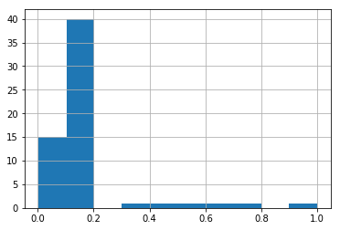

```python
missing_va['na_percentage'].hist()
```

```python
missing_va[missing_va.na_percentage >= 0.3]
```

|  | na_n | na_percentage |
| --- | --- | --- |
| TITEL_KZ | 889061 | 0.997576 |
| AGER_TYP | 685843 | 0.769554 |
| KK_KUNDENTYP | 584612 | 0.655967 |
| KBA05_BAUMAX | 476524 | 0.534687 |
| GEBURTSJAHR | 392318 | 0.440203 |
| ALTER_HH | 310267 | 0.348137 |

```python
col_delt = []
for col in missing_va[missing_va.na_percentage >= 0.3].index:
    col_delt.append(col)
col_delt
```

```
['TITEL_KZ',
 'AGER_TYP',
 'KK_KUNDENTYP',
 'KBA05_BAUMAX',
 'GEBURTSJAHR',
 'ALTER_HH']
```

```python
for col in col_delt:
    azdias_c.drop(col,axis=1,inplace=True)
azdias_c.shape
```

```
(891221, 79)
```

```python
azdias_c.to_csv('df_clean.csv',index=False)
```

```python
df_clean = pd.read_csv('df_clean.csv')
df_clean.head(3)
```

|  | ALTERSKATEGORIE_GROB | ANREDE_KZ | CJT_GESAMTTYP | FINANZ_MINIMALIST | FINANZ_SPARER | FINANZ_VORSORGER | FINANZ_ANLEGER | FINANZ_UNAUFFAELLIGER | FINANZ_HAUSBAUER | FINANZTYP | ... | PLZ8_ANTG1 | PLZ8_ANTG2 | PLZ8_ANTG3 | PLZ8_ANTG4 | PLZ8_BAUMAX | PLZ8_HHZ | PLZ8_GBZ | ARBEIT | ORTSGR_KLS9 | RELAT_AB |
| --- | --- | --- | --- | --- | --- | --- | --- | --- | --- | --- | --- | --- | --- | --- | --- | --- | --- | --- | --- | --- | --- |
| 0 | 2.0 | 1 | 2.0 | 3 | 4 | 3 | 5 | 5 | 3 | 4 | ... | NaN | NaN | NaN | NaN | NaN | NaN | NaN | NaN | NaN | NaN |
| 1 | 1.0 | 2 | 5.0 | 1 | 5 | 2 | 5 | 4 | 5 | 1 | ... | 2.0 | 3.0 | 2.0 | 1.0 | 1.0 | 5.0 | 4.0 | 3.0 | 5.0 | 4.0 |
| 2 | 3.0 | 2 | 3.0 | 1 | 4 | 1 | 2 | 3 | 5 | 1 | ... | 3.0 | 3.0 | 1.0 | 0.0 | 1.0 | 4.0 | 4.0 | 3.0 | 5.0 | 2.0 |

3 rows × 79 columns

#### Step 1.1.3: Assess Missing Data in Each Row

```python
df_clean.isnull().sum(axis=1).sort_values(ascending=False)[:5]
```

```
643174    49
732775    49
472919    48
183108    47
139316    47
dtype: int64
```

```python
df_clean.shape
```

```
(891221, 79)
```

```
''
```

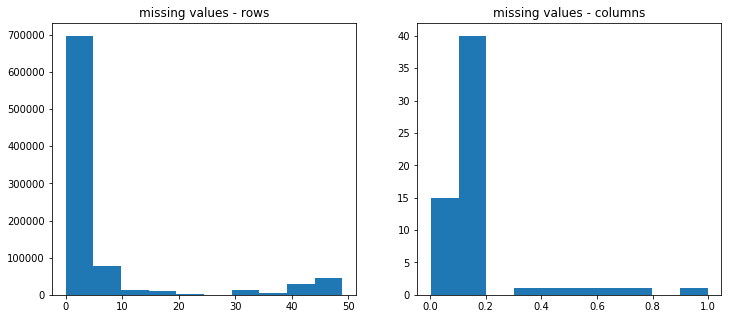

```python
# How much data is missing in each row of the dataset?
plt.figure(figsize=[12,5])

plt.subplot(1,2,1)
plt.hist(df_clean.isnull().sum(axis=1))
plt.title('missing values - rows')

plt.subplot(1,2,2)
plt.hist(missing_va['na_percentage'])
plt.title('missing values - columns')
;
```

```python
# Write code to divide the data into two subsets based on the number of missing
# values in each row.

df_many_na = df_clean[df_clean.isnull().sum(axis=1)>20]
df_many_na.shape
```

```
(93795, 79)
```

```python
df_few_na = df_clean[df_clean.isnull().sum(axis=1)<=20]
df_few_na.shape
```

```
(797426, 79)
```

```python
df_many_na.shape[0] + df_few_na.shape[0]
```

```
891221
```

```python
df_clean.sample()
```

|  | ALTERSKATEGORIE_GROB | ANREDE_KZ | CJT_GESAMTTYP | FINANZ_MINIMALIST | FINANZ_SPARER | FINANZ_VORSORGER | FINANZ_ANLEGER | FINANZ_UNAUFFAELLIGER | FINANZ_HAUSBAUER | FINANZTYP | ... | PLZ8_ANTG1 | PLZ8_ANTG2 | PLZ8_ANTG3 | PLZ8_ANTG4 | PLZ8_BAUMAX | PLZ8_HHZ | PLZ8_GBZ | ARBEIT | ORTSGR_KLS9 | RELAT_AB |
| --- | --- | --- | --- | --- | --- | --- | --- | --- | --- | --- | --- | --- | --- | --- | --- | --- | --- | --- | --- | --- | --- |
| 882925 | 1.0 | 2 | 5.0 | 3 | 3 | 1 | 4 | 5 | 2 | 4 | ... | 4.0 | 2.0 | 0.0 | 0.0 | 1.0 | 4.0 | 5.0 | 2.0 | 3.0 | 1.0 |

1 rows × 79 columns

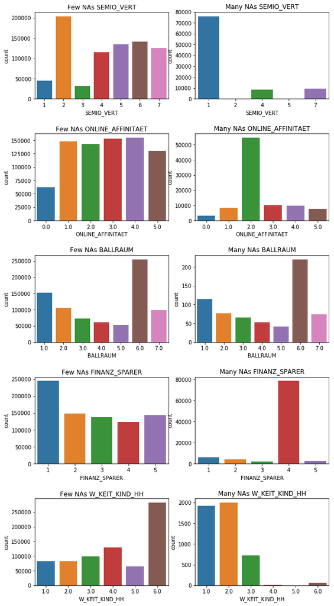

```python
# Compare the distribution of values for at least five columns where there are
# no or few missing values, between the two subsets.
# How much data is missing in each row of the dataset?

import random
cols = []
for i in range(5):
    randd = random.randint(0,df_clean.shape[1]-1)
    cols.append(df_clean.columns[randd])
cols

plt.figure(figsize=[10,20])

count = 1

for col in cols:

    plt.subplot(5,2,count)
    plt.title('Few NAs ' + col)
    sns.countplot(df_few_na[col])
    plt.subplots_adjust(hspace=0.4)

    count+=1

    plt.subplot(5,2,count)
    plt.title('Many NAs ' + col)
    sns.countplot(df_many_na[col])
    plt.subplots_adjust(hspace=0.4)
    count+=1

    ;
```

#### Discussion 1.1.3: Assess Missing Data in Each Row

Interestingly, there seems to be a large difference between those respondents with many (>20) missing values and those with fewer missing values. Iterestingly, by pure chance I discovered that the variable "ONLINE_AFFINITAET" was much lower for those with many missing responses compared witht those wit fuller ones.

### Step 1.2: Select and Re-Encode Features

```python
# How many features are there of each data type?
feat_info.type.value_counts()
```

```
ordinal        49
categorical    21
numeric         7
mixed           7
interval        1
Name: type, dtype: int64
```

```python
feat_info[feat_info.type ==  'mixed']
```

|  | attribute | information_level | type | missing_or_unknown |
| --- | --- | --- | --- | --- |
| 15 | LP_LEBENSPHASE_FEIN | person | mixed | [0] |
| 16 | LP_LEBENSPHASE_GROB | person | mixed | [0] |
| 22 | PRAEGENDE_JUGENDJAHRE | person | mixed | [-1,0] |
| 56 | WOHNLAGE | building | mixed | [-1] |
| 59 | CAMEO_INTL_2015 | microcell_rr4 | mixed | [-1,XX] |
| 64 | KBA05_BAUMAX | microcell_rr3 | mixed | [-1,0] |
| 79 | PLZ8_BAUMAX | macrocell_plz8 | mixed | [-1,0] |

#### Step 1.2.1: Re-Encode Categorical Features

For categorical data, you would ordinarily need to encode the levels as dummy variables. Depending on the number of categories, perform one of the following:

- For binary (two-level) categoricals that take numeric values, you can keep them without needing to do anything.
- There is one binary variable that takes on non-numeric values. For this one, you need to re-encode the values as numbers or create a dummy variable.
- For multi-level categoricals (three or more values), you can choose to encode the values using multiple dummy variables (e.g. via [OneHotEncoder](http://scikit-learn.org/stable/modules/generated/sklearn.preprocessing.OneHotEncoder.html)), or (to keep things straightforward) just drop them from the analysis. As always, document your choices in the Discussion section.

```python
col_delt
```

```
['TITEL_KZ',
 'AGER_TYP',
 'KK_KUNDENTYP',
 'KBA05_BAUMAX',
 'GEBURTSJAHR',
 'ALTER_HH']
```

```python
feat_info_c = feat_info.copy()
feat_info_d = feat_info_c[feat_info_c.attribute.isin(col_delt).values == False]
feat_info_d.shape
```

```
(79, 4)
```

```python
cat_columns = feat_info_d[feat_info.type == 'categorical']['attribute'].values
cat_columns
```

```
array(['ANREDE_KZ', 'CJT_GESAMTTYP', 'FINANZTYP', 'GFK_URLAUBERTYP',
       'GREEN_AVANTGARDE', 'LP_FAMILIE_FEIN', 'LP_FAMILIE_GROB',
       'LP_STATUS_FEIN', 'LP_STATUS_GROB', 'NATIONALITAET_KZ',
       'SHOPPER_TYP', 'SOHO_KZ', 'VERS_TYP', 'ZABEOTYP', 'GEBAEUDETYP',
       'OST_WEST_KZ', 'CAMEO_DEUG_2015', 'CAMEO_DEU_2015'], dtype=object)
```

```python
multi_cat = []
for col in cat_columns:
    if df_clean[col].nunique() > 2:
        multi_cat.append(col)
multi_cat
```

```
['CJT_GESAMTTYP',
 'FINANZTYP',
 'GFK_URLAUBERTYP',
 'LP_FAMILIE_FEIN',
 'LP_FAMILIE_GROB',
 'LP_STATUS_FEIN',
 'LP_STATUS_GROB',
 'NATIONALITAET_KZ',
 'SHOPPER_TYP',
 'ZABEOTYP',
 'GEBAEUDETYP',
 'CAMEO_DEUG_2015',
 'CAMEO_DEU_2015']
```

```python
df_clean.shape
```

```
(891221, 79)
```

Droping variables with multiple categories

```python
for col in multi_cat:
    df_clean.drop(col,axis=1,inplace=True)
df_clean.shape
```

```
(891221, 66)
```

```python
# Re-encode categorical variable(s) to be kept in the analysis.
cat_cols_2 = []
for cat in cat_columns:
    if not cat in multi_cat:
        cat_cols_2.append(cat)
cat_cols_2
```

```
['ANREDE_KZ', 'GREEN_AVANTGARDE', 'SOHO_KZ', 'VERS_TYP', 'OST_WEST_KZ']
```

```python
for cat in cat_cols_2:
    print(df_clean[cat].value_counts())
```

```
2    465305
1    425916
Name: ANREDE_KZ, dtype: int64
0    715996
1    175225
Name: GREEN_AVANTGARDE, dtype: int64
0.0    810834
1.0      6888
Name: SOHO_KZ, dtype: int64
2.0    398722
1.0    381303
Name: VERS_TYP, dtype: int64
W    629528
O    168545
Name: OST_WEST_KZ, dtype: int64
```

```python
df_clean['ANREDE_KZ'].replace([2,1], [1,0], inplace=True)
df_clean['VERS_TYP'].replace([2.0,1.0], [1,0], inplace=True)
df_clean['OST_WEST_KZ'].replace(['W','O'], [1,0], inplace=True)
```

#### Step 1.2.2: Engineer Mixed-Type Features

There are a handful of features that are marked as "mixed" in the feature summary that require special treatment in order to be included in the analysis. There are two in particular that deserve attention; the handling of the rest are up to your own choices:

- "PRAEGENDE_JUGENDJAHRE" combines information on three dimensions: generation by decade, movement (mainstream vs. avantgarde), and nation (east vs. west). While there aren't enough levels to disentangle east from west, you should create two new variables to capture the other two dimensions: an interval-type variable for decade, and a binary variable for movement.
- "CAMEO_INTL_2015" combines information on two axes: wealth and life stage. Break up the two-digit codes by their 'tens'-place and 'ones'-place digits into two new ordinal variables (which, for the purposes of this project, is equivalent to just treating them as their raw numeric values).
- If you decide to keep or engineer new features around the other mixed-type features, make sure you note your steps in the Discussion section.

Be sure to check `Data_Dictionary.md` for the details needed to finish these tasks.

```python
# Investigate "PRAEGENDE_JUGENDJAHRE" and engineer two new variables.

df_clean[['PRAEGENDE_JUGENDJAHRE']][:5]
```

|  | PRAEGENDE_JUGENDJAHRE |
| --- | --- |
| 0 | NaN |
| 1 | 14.0 |
| 2 | 15.0 |
| 3 | 8.0 |
| 4 | 8.0 |

Dominating movement of person's youth (avantgarde vs. mainstream; east vs. west)

- -1: unknown
- 0: unknown
- 1: 40s - war years (Mainstream, E+W)
- 2: 40s - reconstruction years (Avantgarde, E+W)
- 3: 50s - economic miracle (Mainstream, E+W)
- 4: 50s - milk bar / Individualisation (Avantgarde, E+W)
- 5: 60s - economic miracle (Mainstream, E+W)
- 6: 60s - generation 68 / student protestors (Avantgarde, W)
- 7: 60s - opponents to the building of the Wall (Avantgarde, E)
- 8: 70s - family orientation (Mainstream, E+W)
- 9: 70s - peace movement (Avantgarde, E+W)
- 10: 80s - Generation Golf (Mainstream, W)
- 11: 80s - ecological awareness (Avantgarde, W)
- 12: 80s - FDJ / communist party youth organisation (Mainstream, E)
- 13: 80s - Swords into ploughshares (Avantgarde, E)
- 14: 90s - digital media kids (Mainstream, E+W)
- 15: 90s - ecological awareness (Avantgarde, E+W)

```python
dec_dict = {40:[1,2],50:[3,4],60:[5,6,7],70:[8,9],80:[10,11,12,13],90:[14,15]}

for a,b in dec_dict.items():
    print(a,b)
```

```
40 [1, 2]
50 [3, 4]
60 [5, 6, 7]
70 [8, 9]
80 [10, 11, 12, 13]
90 [14, 15]
```

```python
def deca_enco(x):
    try:
        for a,b in dec_dict.items():
            if x in b:
                return int(a)
    except ValueError:
        return np.nan
```

```python
df_clean['PRAEGENDE_JUGENDJAHRE_DECADE'] = df_clean['PRAEGENDE_JUGENDJAHRE'].apply(deca_enco)
df_clean[['PRAEGENDE_JUGENDJAHRE', 'PRAEGENDE_JUGENDJAHRE_DECADE']][:5]
```

|  | PRAEGENDE_JUGENDJAHRE | PRAEGENDE_JUGENDJAHRE_DECADE |
| --- | --- | --- |
| 0 | NaN | NaN |
| 1 | 14.0 | 90.0 |
| 2 | 15.0 | 90.0 |
| 3 | 8.0 | 70.0 |
| 4 | 8.0 | 70.0 |

```python
mainstream = [1,3,5,8,10,12,14]
avantgarde = []
for i in range(1,15):
    if i not in mainstream:
        avantgarde.append(i)
avantgarde
```

```
[2, 4, 6, 7, 9, 11, 13]
```

```python
move = {0:[1,3,5,8,10,12,14],1:[2, 4, 6, 7, 9, 11, 13]}
def move_enco(x):
    try:
        for a, b in move.items():
            if x in b:
                return a
    except ValueError:
        return np.nan
```

```python
for i in range(1,15):
    print(move_enco(i))
```

```
0
1
0
1
0
1
1
0
1
0
1
0
1
0
```

```python
df_clean['PRAEGENDE_JUGENDJAHRE_MOV'] = df_clean['PRAEGENDE_JUGENDJAHRE'].apply(move_enco)
df_clean[['PRAEGENDE_JUGENDJAHRE', 'PRAEGENDE_JUGENDJAHRE_MOV']][:5]
```

|  | PRAEGENDE_JUGENDJAHRE | PRAEGENDE_JUGENDJAHRE_MOV |
| --- | --- | --- |
| 0 | NaN | NaN |
| 1 | 14.0 | 0.0 |
| 2 | 15.0 | NaN |
| 3 | 8.0 | 0.0 |
| 4 | 8.0 | 0.0 |

Investigate "CAMEO_INTL_2015" and engineer two new variables. "CAMEO_INTL_2015" combines information on two axes: wealth and life stage. Break up the two-digit codes by their 'tens'-place and 'ones'-place digits into two new ordinal variables (which, for the purposes of this project, is equivalent to just treating them as their raw numeric values).

```python
df_clean[['CAMEO_INTL_2015']][:5]
```

|  | CAMEO_INTL_2015 |
| --- | --- |
| 0 | NaN |
| 1 | 51.0 |
| 2 | 24.0 |
| 3 | 12.0 |
| 4 | 43.0 |

German CAMEO: Wealth / Life Stage Typology, mapped to international code

- -1: unknown
- 11: Wealthy Households - Pre-Family Couples & Singles
- 12: Wealthy Households - Young Couples With Children
- 13: Wealthy Households - Families With School Age Children
- 14: Wealthy Households - Older Families & Mature Couples
- 15: Wealthy Households - Elders In Retirement
- 21: Prosperous Households - Pre-Family Couples & Singles
- 22: Prosperous Households - Young Couples With Children
- 23: Prosperous Households - Families With School Age Children
- 24: Prosperous Households - Older Families & Mature Couples
- 25: Prosperous Households - Elders In Retirement
- 31: Comfortable Households - Pre-Family Couples & Singles
- 32: Comfortable Households - Young Couples With Children
- 33: Comfortable Households - Families With School Age Children
- 34: Comfortable Households - Older Families & Mature Couples
- 35: Comfortable Households - Elders In Retirement
- 41: Less Affluent Households - Pre-Family Couples & Singles
- 42: Less Affluent Households - Young Couples With Children
- 43: Less Affluent Households - Families With School Age Children
- 44: Less Affluent Households - Older Families & Mature Couples
- 45: Less Affluent Households - Elders In Retirement
- 51: Poorer Households - Pre-Family Couples & Singles
- 52: Poorer Households - Young Couples With Children
- 53: Poorer Households - Families With School Age Children
- 54: Poorer Households - Older Families & Mature Couples
- 55: Poorer Households - Elders In Retirement
- XX: unknown

```python
def wealth_enc(x):
    try:
        wealth = int(str(x)[0])
        if wealth <= 5:
            return(wealth)
        else:
            return np.nan
    except ValueError:
        return np.nan
```

```python
df_clean['CAMEO_INTL_2015_WEALTH'] = df_clean['CAMEO_INTL_2015'].apply(wealth_enc)
df_clean[['CAMEO_INTL_2015','CAMEO_INTL_2015_WEALTH']][:3]
```

|  | CAMEO_INTL_2015 | CAMEO_INTL_2015_WEALTH |
| --- | --- | --- |
| 0 | NaN | NaN |
| 1 | 51.0 | 5.0 |
| 2 | 24.0 | 2.0 |

```python
def fam_enc(x):
    try:
        fam = int(str(x)[1])
        if fam <= 5:
            return(fam)
        else:
            return np.nan
    except ValueError:
        return np.nan
```

```python
df_clean['CAMEO_INTL_2015_FAM'] = df_clean['CAMEO_INTL_2015'].apply(fam_enc)
df_clean[['CAMEO_INTL_2015','CAMEO_INTL_2015_WEALTH','CAMEO_INTL_2015_FAM']][:4]
```

|  | CAMEO_INTL_2015 | CAMEO_INTL_2015_WEALTH | CAMEO_INTL_2015_FAM |
| --- | --- | --- | --- |
| 0 | NaN | NaN | NaN |
| 1 | 51.0 | 5.0 | 1.0 |
| 2 | 24.0 | 2.0 | 4.0 |
| 3 | 12.0 | 1.0 | 2.0 |

#### Discussion 1.2.2: Engineer Mixed-Type Features

In this part I re-engineered some fo the features that contained multiple information in only one cell. I did this by separating the informatio into two columns. The information that was covered was around household wealth and how numerous the family was

#### Step 1.2.3: Complete Feature Selection

In order to finish this step up, you need to make sure that your data frame now only has the columns that you want to keep. To summarize, the dataframe should consist of the following:

- All numeric, interval, and ordinal type columns from the original dataset.
- Binary categorical features (all numerically-encoded).
- Engineered features from other multi-level categorical features and mixed features.

Make sure that for any new columns that you have engineered, that you've excluded the original columns from the final dataset. Otherwise, their values will interfere with the analysis later on the project. For example, you should not keep "PRAEGENDE_JUGENDJAHRE", since its values won't be useful for the algorithm: only the values derived from it in the engineered features you created should be retained. As a reminder, your data should only be from **the subset with few or no missing values**.

```python
df_clean.info()
```

```
<class 'pandas.core.frame.DataFrame'>
RangeIndex: 891221 entries, 0 to 891220
Data columns (total 70 columns):
ALTERSKATEGORIE_GROB            888340 non-null float64
ANREDE_KZ                       891221 non-null int64
FINANZ_MINIMALIST               891221 non-null int64
FINANZ_SPARER                   891221 non-null int64
FINANZ_VORSORGER                891221 non-null int64
FINANZ_ANLEGER                  891221 non-null int64
FINANZ_UNAUFFAELLIGER           891221 non-null int64
FINANZ_HAUSBAUER                891221 non-null int64
GREEN_AVANTGARDE                891221 non-null int64
HEALTH_TYP                      780025 non-null float64
LP_LEBENSPHASE_FEIN             793589 non-null float64
LP_LEBENSPHASE_GROB             796649 non-null float64
PRAEGENDE_JUGENDJAHRE           783057 non-null float64
RETOURTYP_BK_S                  886367 non-null float64
SEMIO_SOZ                       891221 non-null int64
SEMIO_FAM                       891221 non-null int64
SEMIO_REL                       891221 non-null int64
SEMIO_MAT                       891221 non-null int64
SEMIO_VERT                      891221 non-null int64
SEMIO_LUST                      891221 non-null int64
SEMIO_ERL                       891221 non-null int64
SEMIO_KULT                      891221 non-null int64
SEMIO_RAT                       891221 non-null int64
SEMIO_KRIT                      891221 non-null int64
SEMIO_DOM                       891221 non-null int64
SEMIO_KAEM                      891221 non-null int64
SEMIO_PFLICHT                   891221 non-null int64
SEMIO_TRADV                     891221 non-null int64
SOHO_KZ                         817722 non-null float64
VERS_TYP                        780025 non-null float64
ANZ_PERSONEN                    817722 non-null float64
ANZ_TITEL                       817722 non-null float64
HH_EINKOMMEN_SCORE              872873 non-null float64
W_KEIT_KIND_HH                  743233 non-null float64
WOHNDAUER_2008                  817722 non-null float64
ANZ_HAUSHALTE_AKTIV             791610 non-null float64
ANZ_HH_TITEL                    794213 non-null float64
```

[output cut: 20 more lines]

```
PLZ8_ANTG2                      774706 non-null float64
PLZ8_ANTG3                      774706 non-null float64
PLZ8_ANTG4                      774706 non-null float64
PLZ8_BAUMAX                     774706 non-null float64
PLZ8_HHZ                        774706 non-null float64
PLZ8_GBZ                        774706 non-null float64
ARBEIT                          793846 non-null float64
ORTSGR_KLS9                     793947 non-null float64
RELAT_AB                        793846 non-null float64
PRAEGENDE_JUGENDJAHRE_DECADE    783057 non-null float64
PRAEGENDE_JUGENDJAHRE_MOV       740510 non-null float64
CAMEO_INTL_2015_WEALTH          791869 non-null float64
CAMEO_INTL_2015_FAM             791869 non-null float64
dtypes: float64(48), int64(22)
memory usage: 476.0 MB
```

```python
# If there are other re-engineering tasks you need to perform, make sure you
# take care of them here. (Dealing with missing data will come in step 2.1.)
del_cols = ['CAMEO_INTL_2015','PRAEGENDE_JUGENDJAHRE']
for col in del_cols:
    df_clean.drop(col,axis=1,inplace=True)
df_clean.shape
```

```
(891221, 68)
```

```python
# Do whatever you need to in order to ensure that the dataframe only contains
# the columns that should be passed to the algorithm functions.

df_clean.to_csv('df_clean.csv',index=False)
```

### Step 1.3: Create a Cleaning Function

Even though you've finished cleaning up the general population demographics data, it's important to look ahead to the future and realize that you'll need to perform the same cleaning steps on the customer demographics data. In this substep, complete the function below to execute the main feature selection, encoding, and re-engineering steps you performed above. Then, when it comes to looking at the customer data in Step 3, you can just run this function on that DataFrame to get the trimmed dataset in a single step.

```python
df_clean = pd.read_csv('df_clean.csv')
```

```python
def clean_df(df):

    df2 = df.copy()

    df2['ANREDE_KZ'].replace([2,1], [1,0], inplace=True)
    df2['VERS_TYP'].replace([2.0,1.0], [1,0], inplace=True)
    df2['OST_WEST_KZ'].replace(['O','W'],[1,0],inplace=True)
    #Ecncoding PRAEGENDE_JUGENDJAHRE and CAMEO_INTL_2015
    dec_dict = {40:[1,2],50:[3,4],60:[5,6,7],70:[8,9],80:[10,11,12,13],90:[14,15]}
    def deca_enco(x):
        try:
            for a,b in dec_dict.items():
                if x in b:
                    return int(a)
        except ValueError:
            return np.nan

    df2['PRAEGENDE_JUGENDJAHRE_DECADE'] = df2['PRAEGENDE_JUGENDJAHRE'].apply(deca_enco)

    move = {0:[1,3,5,8,10,12,14],1:[2, 4, 6, 7, 9, 11, 13]}
    def move_enco(x):
        try:
            for a, b in move.items():
                if x in b:
                    return a
        except ValueError:
            return np.nan

    df2['PRAEGENDE_JUGENDJAHRE_MOV'] = df2['PRAEGENDE_JUGENDJAHRE'].apply(move_enco)

    def wealth_enc(x):
        try:
            wealth = int(str(x)[0])
            if wealth <= 5:
                return(wealth)
            else:
                return np.nan
        except ValueError:
            return np.nan

    df2['CAMEO_INTL_2015_WEALTH'] = df2['CAMEO_INTL_2015'].apply(wealth_enc)

    def fam_enc(x):
        try:
            fam = int(str(x)[1])
            if fam <= 5:
                return(fam)
            else:
                return np.nan
        except ValueError:
            return np.nan

    df2['CAMEO_INTL_2015_FAM'] = df2['CAMEO_INTL_2015'].apply(fam_enc)

    #Deletee unecessary columns
    # These will be deleted because too many values missing, multi-level categories, too many missing rows

    col_delete = ['TITEL_KZ',
    'AGER_TYP',
    'KK_KUNDENTYP',
    'KBA05_BAUMAX',
    'GEBURTSJAHR',
    'ALTER_HH',
    'CJT_GESAMTTYP',
    'FINANZTYP',
    'GFK_URLAUBERTYP',
    'LP_FAMILIE_FEIN',
    'LP_FAMILIE_GROB',
    'LP_STATUS_FEIN',
    'LP_STATUS_GROB',
    'NATIONALITAET_KZ',
    'SHOPPER_TYP',
    'ZABEOTYP',
    'GEBAEUDETYP',
    'CAMEO_DEUG_2015',
    'CAMEO_DEU_2015',
    'CAMEO_INTL_2015',
    'PRAEGENDE_JUGENDJAHRE']

    for col in col_delete:
        df2.drop(col,axis=1,inplace=True)

    # Remove observations with too many missing values
    df2 = df2[df.isnull().sum(axis=1)<=20]


    return df2
```

```python
azdias.shape
```

```
(891221, 85)
```

## Step 2: Feature Transformation

### Step 2.1: Apply Feature Scaling

Before we apply dimensionality reduction techniques to the data, we need to perform feature scaling so that the principal component vectors are not influenced by the natural differences in scale for features. Starting from this part of the project, you'll want to keep an eye on the [API reference page for sklearn](http://scikit-learn.org/stable/modules/classes.html) to help you navigate to all of the classes and functions that you'll need. In this substep, you'll need to check the following:

- sklearn requires that data not have missing values in order for its estimators to work properly. So, before applying the scaler to your data, make sure that you've cleaned the DataFrame of the remaining missing values. This can be as simple as just removing all data points with missing data, or applying an [Imputer](http://scikit-learn.org/stable/modules/generated/sklearn.preprocessing.Imputer.html) to replace all missing values. You might also try a more complicated procedure where you temporarily remove missing values in order to compute the scaling parameters before re-introducing those missing values and applying imputation. Think about how much missing data you have and what possible effects each approach might have on your analysis, and justify your decision in the discussion section below.
- For the actual scaling function, a [StandardScaler](http://scikit-learn.org/stable/modules/generated/sklearn.preprocessing.StandardScaler.html) instance is suggested, scaling each feature to mean 0 and standard deviation 1.
- For these classes, you can make use of the `.fit_transform()` method to both fit a procedure to the data as well as apply the transformation to the data at the same time. Don't forget to keep the fit sklearn objects handy, since you'll be applying them to the customer demographics data towards the end of the project.

```python
# If you've not yet cleaned the dataset of all NaN values, then investigate and
# do that now.
azdias =  pd.read_csv('Udacity_AZDIAS_Subset.csv',sep=';')
df = clean_df(azdias)
print(df.shape)
df.dropna(inplace=True)
print(df.shape)
```

```
(797416, 68)
(638023, 68)
```

```python
df['OST_WEST_KZ'].value_counts()
```

```
0.0    493128
1.0    144895
Name: OST_WEST_KZ, dtype: int64
```

```python
df_cols = df.columns
df_cols
```

```
Index(['ALTERSKATEGORIE_GROB', 'ANREDE_KZ', 'FINANZ_MINIMALIST',
       'FINANZ_SPARER', 'FINANZ_VORSORGER', 'FINANZ_ANLEGER',
       'FINANZ_UNAUFFAELLIGER', 'FINANZ_HAUSBAUER', 'GREEN_AVANTGARDE',
       'HEALTH_TYP', 'LP_LEBENSPHASE_FEIN', 'LP_LEBENSPHASE_GROB',
       'RETOURTYP_BK_S', 'SEMIO_SOZ', 'SEMIO_FAM', 'SEMIO_REL', 'SEMIO_MAT',
       'SEMIO_VERT', 'SEMIO_LUST', 'SEMIO_ERL', 'SEMIO_KULT', 'SEMIO_RAT',
       'SEMIO_KRIT', 'SEMIO_DOM', 'SEMIO_KAEM', 'SEMIO_PFLICHT', 'SEMIO_TRADV',
       'SOHO_KZ', 'VERS_TYP', 'ANZ_PERSONEN', 'ANZ_TITEL',
       'HH_EINKOMMEN_SCORE', 'W_KEIT_KIND_HH', 'WOHNDAUER_2008',
       'ANZ_HAUSHALTE_AKTIV', 'ANZ_HH_TITEL', 'KONSUMNAEHE',
       'MIN_GEBAEUDEJAHR', 'OST_WEST_KZ', 'WOHNLAGE', 'KBA05_ANTG1',
       'KBA05_ANTG2', 'KBA05_ANTG3', 'KBA05_ANTG4', 'KBA05_GBZ', 'BALLRAUM',
       'EWDICHTE', 'INNENSTADT', 'GEBAEUDETYP_RASTER', 'KKK', 'MOBI_REGIO',
       'ONLINE_AFFINITAET', 'REGIOTYP', 'KBA13_ANZAHL_PKW', 'PLZ8_ANTG1',
       'PLZ8_ANTG2', 'PLZ8_ANTG3', 'PLZ8_ANTG4', 'PLZ8_BAUMAX', 'PLZ8_HHZ',
       'PLZ8_GBZ', 'ARBEIT', 'ORTSGR_KLS9', 'RELAT_AB',
       'PRAEGENDE_JUGENDJAHRE_DECADE', 'PRAEGENDE_JUGENDJAHRE_MOV',
       'CAMEO_INTL_2015_WEALTH', 'CAMEO_INTL_2015_FAM'],
      dtype='object')
```

```python
# Apply feature scaling to the general population demographics data.
from sklearn import preprocessing as p
scaler = p.StandardScaler()
df_ss = scaler.fit_transform(df)
df_ss = pd.DataFrame(df_ss)
df_ss.columns = df_cols
df_ss.head()
```

|  | ALTERSKATEGORIE_GROB | ANREDE_KZ | FINANZ_MINIMALIST | FINANZ_SPARER | FINANZ_VORSORGER | FINANZ_ANLEGER | FINANZ_UNAUFFAELLIGER | FINANZ_HAUSBAUER | GREEN_AVANTGARDE | HEALTH_TYP | ... | PLZ8_BAUMAX | PLZ8_HHZ | PLZ8_GBZ | ARBEIT | ORTSGR_KLS9 | RELAT_AB | PRAEGENDE_JUGENDJAHRE_DECADE | PRAEGENDE_JUGENDJAHRE_MOV | CAMEO_INTL_2015_WEALTH | CAMEO_INTL_2015_FAM |
| --- | --- | --- | --- | --- | --- | --- | --- | --- | --- | --- | --- | --- | --- | --- | --- | --- | --- | --- | --- | --- | --- |
| 0 | -1.723037 | 0.958852 | -1.523080 | 1.635337 | -1.107847 | 1.558408 | 1.157820 | 1.325342 | -0.477287 | 0.962310 | ... | -0.665784 | 1.436191 | 0.585230 | -0.200387 | -0.140348 | 0.667916 | 1.236852 | -0.477287 | 1.142885 | -1.236697 |
| 1 | 0.141454 | -1.042914 | 0.668112 | 0.268440 | 0.348990 | -1.208275 | 0.403318 | -0.868179 | -0.477287 | 0.962310 | ... | 0.012902 | -0.625169 | -0.310489 | 0.803795 | 0.292317 | 1.406367 | -0.157662 | -0.477287 | 0.457424 | 0.096666 |
| 2 | -1.723037 | 0.958852 | -0.062285 | -1.098457 | 1.077409 | -0.516604 | -0.351185 | 1.325342 | -0.477287 | 0.962310 | ... | -0.665784 | 1.436191 | 1.480950 | -1.204569 | -1.005679 | -0.070536 | -1.552176 | -0.477287 | 1.142885 | 0.763348 |
| 3 | -0.790792 | 0.958852 | -1.523080 | 1.635337 | -1.836266 | 1.558408 | 1.157820 | -0.137005 | -0.477287 | -0.161100 | ... | -0.665784 | 1.436191 | 1.480950 | 0.803795 | 0.292317 | -0.070536 | 0.539595 | -0.477287 | -0.913499 | -0.570015 |
| 4 | -1.723037 | -1.042914 | -0.062285 | 0.268440 | 0.348990 | -1.208275 | 0.403318 | -0.868179 | -0.477287 | -1.284509 | ... | -0.665784 | 0.405511 | 0.585230 | -1.204569 | -0.140348 | -0.808987 | -0.157662 | -0.477287 | -1.598961 | 0.763348 |

5 rows × 68 columns

### Discussion 2.1: Apply Feature Scaling

Feature scaling is important because it allows us to compare better the different variables. In this cale, I use the StandardScaler from Sklearn, which helps me normalize the values. Because the StandardScaler returns an array, I had to create a new pandas data frame to include the array in.

### Step 2.2: Perform Dimensionality Reduction

On your scaled data, you are now ready to apply dimensionality reduction techniques.

- Use sklearn's [PCA](http://scikit-learn.org/stable/modules/generated/sklearn.decomposition.PCA.html) class to apply principal component analysis on the data, thus finding the vectors of maximal variance in the data. To start, you should not set any parameters (so all components are computed) or set a number of components that is at least half the number of features (so there's enough features to see the general trend in variability).
- Check out the ratio of variance explained by each principal component as well as the cumulative variance explained. Try plotting the cumulative or sequential values using matplotlib's [`plot()`](https://matplotlib.org/api/_as_gen/matplotlib.pyplot.plot.html) function. Based on what you find, select a value for the number of transformed features you'll retain for the clustering part of the project.
- Once you've made a choice for the number of components to keep, make sure you re-fit a PCA instance to perform the decided-on transformation.

```python
# Apply PCA to the data.
df_ss.shape
```

```
(638023, 68)
```

```python
n_components = 40
```

```python
df_ss.sample(2)
```

|  | ALTERSKATEGORIE_GROB | ANREDE_KZ | FINANZ_MINIMALIST | FINANZ_SPARER | FINANZ_VORSORGER | FINANZ_ANLEGER | FINANZ_UNAUFFAELLIGER | FINANZ_HAUSBAUER | GREEN_AVANTGARDE | HEALTH_TYP | ... | PLZ8_BAUMAX | PLZ8_HHZ | PLZ8_GBZ | ARBEIT | ORTSGR_KLS9 | RELAT_AB | PRAEGENDE_JUGENDJAHRE_DECADE | PRAEGENDE_JUGENDJAHRE_MOV | CAMEO_INTL_2015_WEALTH | CAMEO_INTL_2015_FAM |
| --- | --- | --- | --- | --- | --- | --- | --- | --- | --- | --- | --- | --- | --- | --- | --- | --- | --- | --- | --- | --- | --- |
| 54721 | 1.073699 | -1.042914 | 1.398509 | -1.098457 | 1.077409 | -1.208275 | -1.105687 | -0.137005 | 2.095174 | -0.161100 | ... | -0.665784 | 0.405511 | 0.585230 | -2.208750 | -1.005679 | -1.547439 | -1.552176 | 2.095174 | -0.913499 | -0.570015 |
| 100360 | 0.141454 | 0.958852 | -0.792682 | -1.098457 | 1.077409 | -1.208275 | -1.105687 | 1.325342 | -0.477287 | -1.284509 | ... | 1.370274 | 0.405511 | -1.206208 | 0.803795 | 0.724983 | -0.070536 | -0.157662 | -0.477287 | -0.228038 | 1.430030 |

2 rows × 68 columns

```python
pca = PCA(n_components)
df_pca = pca.fit_transform(df_ss)
```

```python
components = pca.explained_variance_ratio_
cum_com = np.cumsum(components)
num_com = np.arange(n_components)
```

```python
components
```

```
array([ 0.18071285,  0.12501397,  0.09003994,  0.0526878 ,  0.04002495,
        0.03281225,  0.03193817,  0.02647814,  0.02556093,  0.02073014,
        0.02009729,  0.01857604,  0.01801067,  0.01584698,  0.01575797,
        0.0147295 ,  0.01470055,  0.0135368 ,  0.01265073,  0.01203347,
        0.01160607,  0.01117357,  0.01092735,  0.01040429,  0.00982682,
        0.00919478,  0.00785343,  0.0076179 ,  0.00743936,  0.00730609,
        0.00691247,  0.00673787,  0.00634369,  0.00626453,  0.00607186,
        0.00575674,  0.00555973,  0.00503671,  0.00466803,  0.00423969])
```

```
''
```

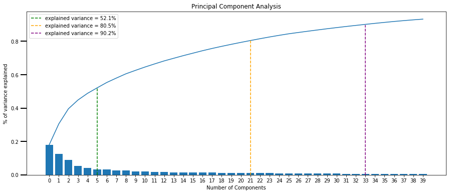

```python
plt.figure(figsize=(15,6))
ax = plt.subplot(111)
ax.plot(num_com,cum_com)
ax.bar(num_com,components)

ax.yaxis.set_tick_params(width=2, length=12)
plt.xticks(num_com)
plt.title('Principal Component Analysis')
plt.xlabel('Number of Components')
plt.ylabel('% of variance explained')
#ax.set_xlim(-0.5, n_components)

# Drawing vertical lines to give when 50%, 80%, 90% and 95% of the variance is explained
thres = [0.5,0.8,0.9]
colors = ['green','orange','purple']
count = 0
for p in thres:
    n_c = len(cum_com[cum_com<=p])
    y_max = cum_com[n_c]
    plt.axvline(x=n_c,ymax=y_max +0.015,linestyle='dashed',color=colors[count],label='explained variance = {0:.01f}%'.format(y_max*100))
    plt.legend()
    count +=1
    #plt.axhline(y=y_max,xmax=(n_c-0.5)/(len(num_com)-0.5))
;
```

```python
n_components = 34
pca_fin = PCA(n_components)
df_pca_fin = pca_fin.fit_transform(df_ss)
```

### Step 2.3: Interpret Principal Components

Now that we have our transformed principal components, it's a nice idea to check out the weight of each variable on the first few components to see if they can be interpreted in some fashion.

As a reminder, each principal component is a unit vector that points in the direction of highest variance (after accounting for the variance captured by earlier principal components). The further a weight is from zero, the more the principal component is in the direction of the corresponding feature. If two features have large weights of the same sign (both positive or both negative), then increases in one tend expect to be associated with increases in the other. To contrast, features with different signs can be expected to show a negative correlation: increases in one variable should result in a decrease in the other.

- To investigate the features, you should map each weight to their corresponding feature name, then sort the features according to weight. The most interesting features for each principal component, then, will be those at the beginning and end of the sorted list. Use the data dictionary document to help you understand these most prominent features, their relationships, and what a positive or negative value on the principal component might indicate.
- You should investigate and interpret feature associations from the first three principal components in this substep. To help facilitate this, you should write a function that you can call at any time to print the sorted list of feature weights, for the *i*-th principal component. This might come in handy in the next step of the project, when you interpret the tendencies of the discovered clusters.

```python
dimensions = ['Dimension {}'.format(i) for i in range(1,len(pca_fin.components_)+1)]
dimensions
```

```
['Dimension 1',
 'Dimension 2',
 'Dimension 3',
 'Dimension 4',
 'Dimension 5',
 'Dimension 6',
 'Dimension 7',
 'Dimension 8',
 'Dimension 9',
 'Dimension 10',
 'Dimension 11',
 'Dimension 12',
 'Dimension 13',
 'Dimension 14',
 'Dimension 15',
 'Dimension 16',
 'Dimension 17',
 'Dimension 18',
 'Dimension 19',
 'Dimension 20',
 'Dimension 21',
 'Dimension 22',
 'Dimension 23',
 'Dimension 24',
 'Dimension 25',
 'Dimension 26',
 'Dimension 27',
 'Dimension 28',
 'Dimension 29',
 'Dimension 30',
 'Dimension 31',
 'Dimension 32',
 'Dimension 33',
 'Dimension 34']
```

```python
components = pd.DataFrame(np.round(pca_fin.components_,4), columns = df_ss.keys())
components[:2]
```

|  | ALTERSKATEGORIE_GROB | ANREDE_KZ | FINANZ_MINIMALIST | FINANZ_SPARER | FINANZ_VORSORGER | FINANZ_ANLEGER | FINANZ_UNAUFFAELLIGER | FINANZ_HAUSBAUER | GREEN_AVANTGARDE | HEALTH_TYP | ... | PLZ8_BAUMAX | PLZ8_HHZ | PLZ8_GBZ | ARBEIT | ORTSGR_KLS9 | RELAT_AB | PRAEGENDE_JUGENDJAHRE_DECADE | PRAEGENDE_JUGENDJAHRE_MOV | CAMEO_INTL_2015_WEALTH | CAMEO_INTL_2015_FAM |
| --- | --- | --- | --- | --- | --- | --- | --- | --- | --- | --- | --- | --- | --- | --- | --- | --- | --- | --- | --- | --- | --- |
| 0 | -0.1149 | 0.0059 | -0.2105 | 0.1468 | -0.1207 | 0.0700 | 0.0843 | 0.1484 | -0.1140 | 0.0165 | ... | 0.2027 | 0.0388 | -0.1593 | 0.1335 | 0.1846 | 0.1235 | 0.1088 | -0.1140 | 0.1947 | -0.1182 |
| 1 | 0.2409 | 0.0765 | 0.0727 | -0.2353 | 0.2310 | -0.2167 | -0.2198 | 0.1073 | 0.0496 | -0.0523 | ... | 0.0907 | 0.0213 | -0.0729 | 0.0719 | 0.1144 | 0.0735 | -0.2492 | 0.0496 | 0.0604 | 0.0058 |

2 rows × 68 columns

```python
ratios = pca_fin.explained_variance_ratio_.reshape(len(pca_fin.components_),1)
variance_ratios = pd.DataFrame(np.round(ratios,4), columns = ['explained variance'])
```

```python
sum(ratios)
```

```
array([ 0.90147776])
```

```python
variance_ratios[:3]
```

|  | explained variance |
| --- | --- |
| 0 | 0.1807 |
| 1 | 0.1250 |
| 2 | 0.0900 |

```python
compn = components.iloc[0]
compn.sort_values(ascending=False, inplace = True)
compn = pd.concat([compn.head(5),compn.tail(5)])
compn
```

```
PLZ8_ANTG3                0.2119
PLZ8_ANTG4                0.2069
PLZ8_BAUMAX               0.2027
HH_EINKOMMEN_SCORE        0.1953
CAMEO_INTL_2015_WEALTH    0.1947
KBA05_GBZ                -0.2051
FINANZ_MINIMALIST        -0.2105
PLZ8_ANTG1               -0.2128
KBA05_ANTG1              -0.2138
MOBI_REGIO               -0.2289
Name: 0, dtype: float64
```

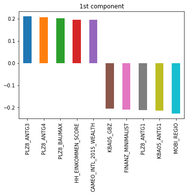

```python
compn.plot(kind='bar', title = '1st component')
```

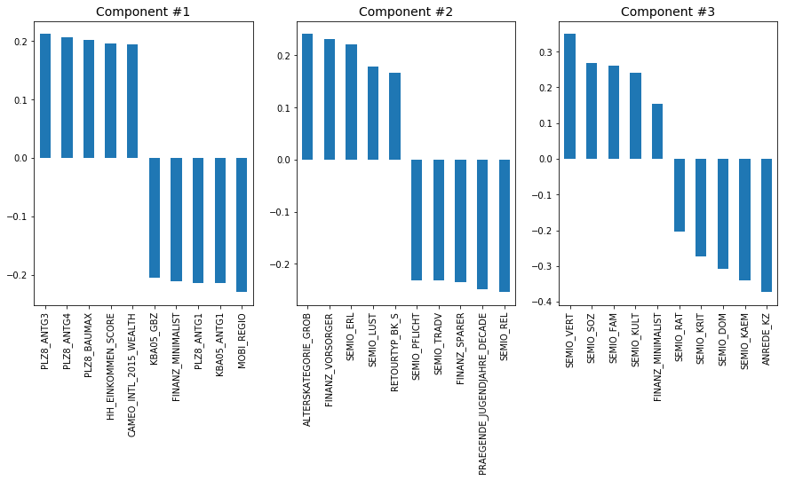

```python
n_comp = 3
base_color = sns.color_palette()[0]


plt.figure(figsize=[15,20])
for comp in range(0,n_comp):
    compn = components.iloc[comp]
    compn.sort_values(ascending=False, inplace=True)
    compn = pd.concat([compn.head(5),compn.tail(5)])

    plt.subplot(n_comp,3,comp+1)
    plt.xticks(fontsize=10)
    plt.yticks(fontsize=10)
    plt.title('Component #' + str(comp+1),fontsize=14)
    compn.plot(kind='bar',color=base_color)
```

#### Selected Elements of Component 1

PLZ8_ANTG3 Number of 6-10 family houses in the PLZ8 region

- -1: unknown
- 0: no 6-10 family homes
- 1: lower share of 6-10 family homes
- 2: average share of 6-10 family homes
- 3: high share of 6-10 family homes

LZ8_ANTG4 Number of 10+ family houses in the PLZ8 region

- -1: unknown
- 0: no 10+ family homes
- 1: lower share of 10+ family homes
- 2: high share of 10+ family homes

Number of 1-2 family houses in the microcell

- -1: unknown
- 0: no 1-2 family homes
- 1: lower share of 1-2 family homes
- 2: average share of 1-2 family homes
- 3: high share of 1-2 family homes
- 4: very high share of 1-2 family homes

7.3. MOBI_REGIO Movement patterns

- 1: very high movement
- 2: high movement
- 3: middle movement
- 4: low movement
- 5: very low movement
- 6: none

#### Selected elementes of Component 2

ALTERSKATEGORIE_GROB Estimated age based on given name analysis

- -1: unknown (missing)
- 0: unknown (cannot be determined)
- 1: < 30 years old
- 2: 30 - 45 years old
- 3: 46 - 60 years old
- 4: > 60 years old
- 9: uniformly distributed

FINANZ_MINIMALIST, FINANZ_SPARER, FINANZ_VORSORGER, FINANZ_ANLEGER, FINANZ_UNAUFFAELLIGER, FINANZ_HAUSBAUER Financial typology, for each dimension:

- -1: unknown
- 1: very high
- 2: high
- 3: average
- 4: low
- 5: very low

Personality typology, for each dimension:

- -1: unknown
- 1: highest affinity
- 2: very high affinity
- 3: high affinity
- 4: average affinity
- 5: low affinity
- 6: very low affinity
- 7: lowest affinity
- 9: unknown

Dimension translations:

- SOZ: socially-minded
- FAM: family-minded
- REL: religious
- MAT: materialistic
- VERT: dreamful
- LUST: sensual-minded
- ERL: event-oriented
- KULT: cultural-minded
- RAT: rational
- KRIT: critical-minded
- DOM: dominant-minded
- KAEM: combative attitude
- PFLICHT: dutiful
- TRADV: tradional-minded

### Discussion 2.3: Interpret Principal Components

The first component seems to be associated with the home size, particularly on large homes. The second component seems to revolve around mind-set, capturing those who seem more open minded and less religious.

The third component seems to be capture how we relate to each other, how oriented to family we are, etc.

## Step 3: Clustering

### Step 3.1: Apply Clustering to General Population

You've assessed and cleaned the demographics data, then scaled and transformed them. Now, it's time to see how the data clusters in the principal components space. In this substep, you will apply k-means clustering to the dataset and use the average within-cluster distances from each point to their assigned cluster's centroid to decide on a number of clusters to keep.

- Use sklearn's KMeans class to perform k-means clustering on the PCA-transformed data.
- Then, compute the average difference from each point to its assigned cluster's center. **Hint**: The KMeans object's `.score()` method might be useful here, but note that in sklearn, scores tend to be defined so that larger is better. Try applying it to a small, toy dataset, or use an internet search to help your understanding.
- Perform the above two steps for a number of different cluster counts. You can then see how the average distance decreases with an increasing number of clusters. However, each additional cluster provides a smaller net benefit. Use this fact to select a final number of clusters in which to group the data. **Warning**: because of the large size of the dataset, it can take a long time for the algorithm to resolve. The more clusters to fit, the longer the algorithm will take. You should test for cluster counts through at least 10 clusters to get the full picture, but you shouldn't need to test for a number of clusters above about 30.
- Once you've selected a final number of clusters to use, re-fit a KMeans instance to perform the clustering operation. Make sure that you also obtain the cluster assignments for the general demographics data, since you'll be using them in the final Step 3.3.

```python
k_n = 3
k_means = KMeans(3)
k_model = k_means.fit(df_ss)
k_labels = k_model.predict(df_ss)
```

```python
for comp in range(0,n_comp):
    compn = components.iloc[comp]
    compn.sort_values(ascending=False, inplace=True)
    print(compn.head(1))
```

```
PLZ8_ANTG3    0.2119
Name: 0, dtype: float64
ALTERSKATEGORIE_GROB    0.2409
Name: 1, dtype: float64
SEMIO_VERT    0.3491
Name: 2, dtype: float64
```

```python
from mpl_toolkits.mplot3d import Axes3D
```

```python
def plot_data2(data, labels):
    '''
    Plot data with colors associated with labels
    '''
    fig = plt.figure();
    ax = Axes3D(fig)
    ax.scatter(data[['PLZ8_ANTG3']], data[['ALTERSKATEGORIE_GROB']], data[['SEMIO_VERT']], c=labels, cmap='tab10');
```

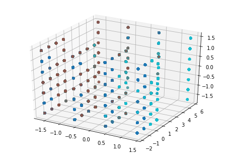

```python
plot_data2(df_ss,k_labels)
```

This was a nice try trying to visualze the clusters with K=3. Although there is some logic to the clustering, it's still not as clear to visualize. OK, let's go to more objective measures, such as calculating the SSE (standard squared error).

```python
score = np.abs(k_model.score(df_ss))
score
```

```
34764096.014377654
```

### Now let's try calculating the SSE for a series of Ks

```python
start_time = time.time()
print(start_time)
print("--- Run time: %s mins ---" % np.round(((time.time() - start_time)/60),2))
```

```
1560696798.2373853
--- Run time: 0.0 mins ---
```

```python
k_n = []
k_n_score = []

start_time = time.time()

for i in range(0,15):

    kmeans = KMeans(i+1)
    model = kmeans.fit(df_ss)
    score = np.abs(model.score(df_ss))
    k_n.append(i+1)
    k_n_score.append(score)
    print('--- run time for round with K = {} : {} mins ---'.format(i+1,np.round(((time.time() - start_time)/60),2)))
k_score_table = pd.DataFrame()
k_score_table['k_n'] = k_n
k_score_table['k_n_score'] = k_n_score
print('--total run time : %s mins -- ' % np.round(((time.time() - start_time)/60),2))

k_score_table
```

```
--- run time for round with K = 1 : 0.25 mins ---
--- run time for round with K = 2 : 0.85 mins ---
--- run time for round with K = 3 : 1.78 mins ---
--- run time for round with K = 4 : 3.01 mins ---
--- run time for round with K = 5 : 4.46 mins ---
--- run time for round with K = 6 : 6.02 mins ---
--- run time for round with K = 7 : 7.96 mins ---
--- run time for round with K = 8 : 10.36 mins ---
--- run time for round with K = 9 : 12.7 mins ---
--- run time for round with K = 10 : 15.39 mins ---
--- run time for round with K = 11 : 19.05 mins ---
--- run time for round with K = 12 : 23.53 mins ---
--- run time for round with K = 13 : 27.23 mins ---
--- run time for round with K = 14 : 32.89 mins ---
--- run time for round with K = 15 : 37.51 mins ---
--total run time : 37.51 mins --
```

|  | k_n | k_n_score |
| --- | --- | --- |
| 0 | 1 | 4.338556e+07 |
| 1 | 2 | 3.754896e+07 |
| 2 | 3 | 3.476409e+07 |
| 3 | 4 | 3.314206e+07 |
| 4 | 5 | 3.190544e+07 |
| 5 | 6 | 3.083607e+07 |
| 6 | 7 | 2.990377e+07 |
| 7 | 8 | 2.927879e+07 |
| 8 | 9 | 2.867180e+07 |
| 9 | 10 | 2.805335e+07 |
| 10 | 11 | 2.774661e+07 |
| 11 | 12 | 2.716012e+07 |
| 12 | 13 | 2.681233e+07 |
| 13 | 14 | 2.656788e+07 |
| 14 | 15 | 2.633641e+07 |

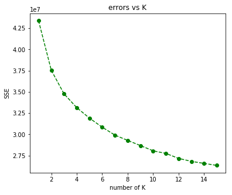

```python
plt.figure(figsize=(6,5))
plt.plot(k_score_table.k_n,k_score_table.k_n_score,linestyle='--',marker= 'o', color='g')
plt.xlabel('number of K')
plt.ylabel('SSE')
plt.title('errors vs K');
```

Based on this analysis, although the 'elbow'is not as clear, the number of K I will proceed with is: 12

```python
k_n = 12
k_means = KMeans(k_n)
k_model = k_means.fit(df_ss)
k_labels = k_model.predict(df_ss)
```

```python
#After PCA
k_n = 12
k_means_pca = KMeans(k_n)
k_model_pca = k_means_pca.fit(df_pca_fin)
k_labels_pca = k_model_pca.predict(df_pca_fin)
```

```python
np.unique(k_labels), np.unique(k_labels_pca)
```

```
(array([ 0,  1,  2,  3,  4,  5,  6,  7,  8,  9, 10, 11], dtype=int32),
 array([ 0,  1,  2,  3,  4,  5,  6,  7,  8,  9, 10, 11], dtype=int32))
```

```python
k_means
```

```
KMeans(algorithm='auto', copy_x=True, init='k-means++', max_iter=300,
    n_clusters=12, n_init=10, n_jobs=1, precompute_distances='auto',
    random_state=None, tol=0.0001, verbose=0)
```

### Discussion 3.1: Apply Clustering to General Population

I decided to use 12 clusters. Althoguh there was not a very clear 'hockey stick' : that is, a point were an additional cluster adds almost no value, we already were approaching the point of diminishing marginal returns. An additional cluster would not have been a game changer.

### Step 3.2: Apply All Steps to the Customer Data

Now that you have clusters and cluster centers for the general population, it's time to see how the customer data maps on to those clusters. Take care to not confuse this for re-fitting all of the models to the customer data. Instead, you're going to use the fits from the general population to clean, transform, and cluster the customer data. In the last step of the project, you will interpret how the general population fits apply to the customer data.

- Don't forget when loading in the customers data, that it is semicolon (`;`) delimited.
- Apply the same feature wrangling, selection, and engineering steps to the customer demographics using the `clean_data()` function you created earlier. (You can assume that the customer demographics data has similar meaning behind missing data patterns as the general demographics data.)
- Use the sklearn objects from the general demographics data, and apply their transformations to the customers data. That is, you should not be using a `.fit()` or `.fit_transform()` method to re-fit the old objects, nor should you be creating new sklearn objects! Carry the data through the feature scaling, PCA, and clustering steps, obtaining cluster assignments for all of the data in the customer demographics data.

```python
# Load in the customer demographics data.
customers = pd.read_csv('Udacity_CUSTOMERS_Subset.csv', sep=';')
customers.shape
```

```
(191652, 85)
```

```python
customers_clean = clean_df(customers)
customers_clean.dropna(inplace=True)
customers_clean.shape
```

```
(120390, 68)
```

```python
customers_clean.columns
```

```
Index(['ALTERSKATEGORIE_GROB', 'ANREDE_KZ', 'FINANZ_MINIMALIST',
       'FINANZ_SPARER', 'FINANZ_VORSORGER', 'FINANZ_ANLEGER',
       'FINANZ_UNAUFFAELLIGER', 'FINANZ_HAUSBAUER', 'GREEN_AVANTGARDE',
       'HEALTH_TYP', 'LP_LEBENSPHASE_FEIN', 'LP_LEBENSPHASE_GROB',
       'RETOURTYP_BK_S', 'SEMIO_SOZ', 'SEMIO_FAM', 'SEMIO_REL', 'SEMIO_MAT',
       'SEMIO_VERT', 'SEMIO_LUST', 'SEMIO_ERL', 'SEMIO_KULT', 'SEMIO_RAT',
       'SEMIO_KRIT', 'SEMIO_DOM', 'SEMIO_KAEM', 'SEMIO_PFLICHT', 'SEMIO_TRADV',
       'SOHO_KZ', 'VERS_TYP', 'ANZ_PERSONEN', 'ANZ_TITEL',
       'HH_EINKOMMEN_SCORE', 'W_KEIT_KIND_HH', 'WOHNDAUER_2008',
       'ANZ_HAUSHALTE_AKTIV', 'ANZ_HH_TITEL', 'KONSUMNAEHE',
       'MIN_GEBAEUDEJAHR', 'OST_WEST_KZ', 'WOHNLAGE', 'KBA05_ANTG1',
       'KBA05_ANTG2', 'KBA05_ANTG3', 'KBA05_ANTG4', 'KBA05_GBZ', 'BALLRAUM',
       'EWDICHTE', 'INNENSTADT', 'GEBAEUDETYP_RASTER', 'KKK', 'MOBI_REGIO',
       'ONLINE_AFFINITAET', 'REGIOTYP', 'KBA13_ANZAHL_PKW', 'PLZ8_ANTG1',
       'PLZ8_ANTG2', 'PLZ8_ANTG3', 'PLZ8_ANTG4', 'PLZ8_BAUMAX', 'PLZ8_HHZ',
       'PLZ8_GBZ', 'ARBEIT', 'ORTSGR_KLS9', 'RELAT_AB',
       'PRAEGENDE_JUGENDJAHRE_DECADE', 'PRAEGENDE_JUGENDJAHRE_MOV',
       'CAMEO_INTL_2015_WEALTH', 'CAMEO_INTL_2015_FAM'],
      dtype='object')
```

```python
df_ss.columns
```

```
Index(['ALTERSKATEGORIE_GROB', 'ANREDE_KZ', 'FINANZ_MINIMALIST',
       'FINANZ_SPARER', 'FINANZ_VORSORGER', 'FINANZ_ANLEGER',
       'FINANZ_UNAUFFAELLIGER', 'FINANZ_HAUSBAUER', 'GREEN_AVANTGARDE',
       'HEALTH_TYP', 'LP_LEBENSPHASE_FEIN', 'LP_LEBENSPHASE_GROB',
       'RETOURTYP_BK_S', 'SEMIO_SOZ', 'SEMIO_FAM', 'SEMIO_REL', 'SEMIO_MAT',
       'SEMIO_VERT', 'SEMIO_LUST', 'SEMIO_ERL', 'SEMIO_KULT', 'SEMIO_RAT',
       'SEMIO_KRIT', 'SEMIO_DOM', 'SEMIO_KAEM', 'SEMIO_PFLICHT', 'SEMIO_TRADV',
       'SOHO_KZ', 'VERS_TYP', 'ANZ_PERSONEN', 'ANZ_TITEL',
       'HH_EINKOMMEN_SCORE', 'W_KEIT_KIND_HH', 'WOHNDAUER_2008',
       'ANZ_HAUSHALTE_AKTIV', 'ANZ_HH_TITEL', 'KONSUMNAEHE',
       'MIN_GEBAEUDEJAHR', 'OST_WEST_KZ', 'WOHNLAGE', 'KBA05_ANTG1',
       'KBA05_ANTG2', 'KBA05_ANTG3', 'KBA05_ANTG4', 'KBA05_GBZ', 'BALLRAUM',
       'EWDICHTE', 'INNENSTADT', 'GEBAEUDETYP_RASTER', 'KKK', 'MOBI_REGIO',
       'ONLINE_AFFINITAET', 'REGIOTYP', 'KBA13_ANZAHL_PKW', 'PLZ8_ANTG1',
       'PLZ8_ANTG2', 'PLZ8_ANTG3', 'PLZ8_ANTG4', 'PLZ8_BAUMAX', 'PLZ8_HHZ',
       'PLZ8_GBZ', 'ARBEIT', 'ORTSGR_KLS9', 'RELAT_AB',
       'PRAEGENDE_JUGENDJAHRE_DECADE', 'PRAEGENDE_JUGENDJAHRE_MOV',
       'CAMEO_INTL_2015_WEALTH', 'CAMEO_INTL_2015_FAM'],
      dtype='object')
```

```python
from sklearn import preprocessing as p
dfc_cols = customers_clean.columns
customers_clean = scaler.transform(customers_clean)
customers_clean = pd.DataFrame(customers_clean)
customers_clean.columns = dfc_cols
customers_clean.head()
```

|  | ALTERSKATEGORIE_GROB | ANREDE_KZ | FINANZ_MINIMALIST | FINANZ_SPARER | FINANZ_VORSORGER | FINANZ_ANLEGER | FINANZ_UNAUFFAELLIGER | FINANZ_HAUSBAUER | GREEN_AVANTGARDE | HEALTH_TYP | ... | PLZ8_BAUMAX | PLZ8_HHZ | PLZ8_GBZ | ARBEIT | ORTSGR_KLS9 | RELAT_AB | PRAEGENDE_JUGENDJAHRE_DECADE | PRAEGENDE_JUGENDJAHRE_MOV | CAMEO_INTL_2015_WEALTH | CAMEO_INTL_2015_FAM |
| --- | --- | --- | --- | --- | --- | --- | --- | --- | --- | --- | --- | --- | --- | --- | --- | --- | --- | --- | --- | --- | --- |
| 0 | 1.073699 | -1.042914 | 1.398509 | -1.098457 | 1.077409 | -1.208275 | -0.351185 | -0.868179 | 2.095174 | -1.284509 | ... | -0.665784 | 1.436191 | 1.480950 | -2.208750 | -1.438344 | -1.547439 | -1.552176 | 2.095174 | -1.598961 | 0.096666 |
| 1 | 1.073699 | 0.958852 | 1.398509 | -1.098457 | 1.077409 | -1.208275 | 1.157820 | 0.594168 | 2.095174 | -0.161100 | ... | 0.691588 | -0.625169 | -1.206208 | -0.200387 | -0.140348 | -0.070536 | -1.552176 | 2.095174 | -0.228038 | 0.763348 |
| 2 | 0.141454 | -1.042914 | -0.062285 | -1.098457 | 0.348990 | 0.866737 | 1.912323 | -0.868179 | -0.477287 | 0.962310 | ... | 0.012902 | -0.625169 | -0.310489 | -0.200387 | -0.140348 | -1.547439 | -0.157662 | -0.477287 | 0.457424 | -1.236697 |
| 3 | 0.141454 | -1.042914 | 1.398509 | -1.098457 | 1.077409 | -1.208275 | -0.351185 | -0.137005 | 2.095174 | 0.962310 | ... | -0.665784 | 1.436191 | 1.480950 | -0.200387 | 0.724983 | 1.406367 | -1.552176 | 2.095174 | -0.228038 | 0.763348 |
| 4 | 1.073699 | -1.042914 | 1.398509 | -1.098457 | 1.077409 | -1.208275 | -1.105687 | -0.868179 | 2.095174 | -0.161100 | ... | -0.665784 | 1.436191 | 1.480950 | -1.204569 | -1.005679 | -0.808987 | -1.552176 | 2.095174 | -0.913499 | 0.096666 |

5 rows × 68 columns

```python
customers_clean[:4]
```

[output not shown]

4 rows × 68 columns

```python
customers_pca = pca_fin.transform(customers_clean)
```

```python
customers_pca
```

```
array([[-6.03765867,  0.78381682,  4.09193131, ...,  0.81710114,
        -0.88132363,  0.19124245],
       [-1.42669416,  5.14726005, -0.76159981, ..., -0.68603124,
        -0.44061122,  0.15785099],
       [ 1.05543591, -1.11664965,  1.34659183, ...,  0.3576579 ,
        -0.17475603,  0.17120044],
       ...,
       [-5.05914703,  2.67979866,  2.33851306, ..., -0.74450964,
         0.56849294, -0.24331011],
       [-1.48215055,  2.38048585, -2.14589042, ..., -0.6221937 ,
         0.36590207,  0.02266966],
       [-4.17287886, -3.27587224,  2.34364803, ..., -0.4796223 ,
         0.33981029, -0.34869413]])
```

```python
df_pca_fin.shape
```

```
(638023, 34)
```

```python
customers_pca.shape
```

```
(120390, 34)
```

```python
k_model_pca
```

```
KMeans(algorithm='auto', copy_x=True, init='k-means++', max_iter=300,
    n_clusters=12, n_init=10, n_jobs=1, precompute_distances='auto',
    random_state=None, tol=0.0001, verbose=0)
```

```python
customers_cluster = k_model_pca.predict(customers_pca)
```

```python
np.unique(customers_cluster)
```

```
array([ 0,  1,  2,  3,  4,  5,  6,  7,  8,  9, 10, 11], dtype=int32)
```

```python
len(customers_cluster)
```

```
120390
```

```python
customers_cluster
```

[output not shown]

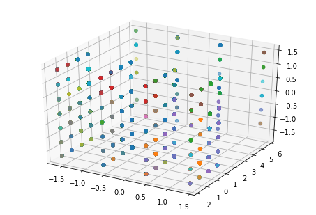

```python
plot_data2(customers_clean, customers_cluster)
```

### Step 3.3: Compare Customer Data to Demographics Data

At this point, you have clustered data based on demographics of the general population of Germany, and seen how the customer data for a mail-order sales company maps onto those demographic clusters. In this final substep, you will compare the two cluster distributions to see where the strongest customer base for the company is.

Consider the proportion of persons in each cluster for the general population, and the proportions for the customers. If we think the company's customer base to be universal, then the cluster assignment proportions should be fairly similar between the two. If there are only particular segments of the population that are interested in the company's products, then we should see a mismatch from one to the other. If there is a higher proportion of persons in a cluster for the customer data compared to the general population (e.g. 5% of persons are assigned to a cluster for the general population, but 15% of the customer data is closest to that cluster's centroid) then that suggests the people in that cluster to be a target audience for the company. On the other hand, the proportion of the data in a cluster being larger in the general population than the customer data (e.g. only 2% of customers closest to a population centroid that captures 6% of the data) suggests that group of persons to be outside of the target demographics.

Take a look at the following points in this step:

- Compute the proportion of data points in each cluster for the general population and the customer data. Visualizations will be useful here: both for the individual dataset proportions, but also to visualize the ratios in cluster representation between groups. Seaborn's [`countplot()`](https://seaborn.pydata.org/generated/seaborn.countplot.html) or [`barplot()`](https://seaborn.pydata.org/generated/seaborn.barplot.html) function could be handy.
  - Recall the analysis you performed in step 1.1.3 of the project, where you separated out certain data points from the dataset if they had more than a specified threshold of missing values. If you found that this group was qualitatively different from the main bulk of the data, you should treat this as an additional data cluster in this analysis. Make sure that you account for the number of data points in this subset, for both the general population and customer datasets, when making your computations!
- Which cluster or clusters are overrepresented in the customer dataset compared to the general population? Select at least one such cluster and infer what kind of people might be represented by that cluster. Use the principal component interpretations from step 2.3 or look at additional components to help you make this inference. Alternatively, you can use the `.inverse_transform()` method of the PCA and StandardScaler objects to transform centroids back to the original data space and interpret the retrieved values directly.
- Perform a similar investigation for the underrepresented clusters. Which cluster or clusters are underrepresented in the customer dataset compared to the general population, and what kinds of people are typified by these clusters?

```python
(customers_cluster==5).sum()/len(customers_cluster)
```

```
0.0787606944098347
```

```python
pop_gen, pop_cus = [], []

for i in np.unique(customers_cluster):
    gen = (k_labels_pca == i).sum() / len(k_labels_pca)
    pop_gen.append(gen)

    cus = (customers_cluster == i).sum() / len(customers_cluster)
    pop_cus.append(cus)
```

```python
df_comp = pd.DataFrame()
df_comp['cluster'] = [i for i in range(len(pop_gen))]
df_comp['general_pop'] = pop_gen
df_comp['customer_pop'] = pop_cus
df_comp
```

|  | cluster | general_pop | customer_pop |
| --- | --- | --- | --- |
| 0 | 0 | 0.090874 | 0.067605 |
| 1 | 1 | 0.124742 | 0.413498 |
| 2 | 2 | 0.093357 | 0.007202 |
| 3 | 3 | 0.113726 | 0.099086 |
| 4 | 4 | 0.071062 | 0.013830 |
| 5 | 5 | 0.114936 | 0.078761 |
| 6 | 6 | 0.076902 | 0.007069 |
| 7 | 7 | 0.003893 | 0.020641 |
| 8 | 8 | 0.091251 | 0.009718 |
| 9 | 9 | 0.069438 | 0.099095 |
| 10 | 10 | 0.056674 | 0.036033 |
| 11 | 11 | 0.093146 | 0.147462 |

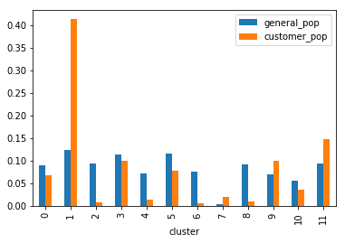

```python
df_comp.plot(x='cluster', y = ['general_pop','customer_pop'], kind='bar')
```

```python
type(customers_clean2)
```

[output not shown]

```python
customers_clean2 = scaler.inverse_transform(customers_clean)
customers_clean2 = pd.DataFrame(data=customers_clean2, columns=customers_clean.columns)
customers_clean2['cluster'] = customers_cluster
customers_clean2[customers_clean2.cluster == 1].sample(10)
```

|  | ALTERSKATEGORIE_GROB | ANREDE_KZ | FINANZ_MINIMALIST | FINANZ_SPARER | FINANZ_VORSORGER | FINANZ_ANLEGER | FINANZ_UNAUFFAELLIGER | FINANZ_HAUSBAUER | GREEN_AVANTGARDE | HEALTH_TYP | ... | PLZ8_HHZ | PLZ8_GBZ | ARBEIT | ORTSGR_KLS9 | RELAT_AB | PRAEGENDE_JUGENDJAHRE_DECADE | PRAEGENDE_JUGENDJAHRE_MOV | CAMEO_INTL_2015_WEALTH | CAMEO_INTL_2015_FAM | cluster |
| --- | --- | --- | --- | --- | --- | --- | --- | --- | --- | --- | --- | --- | --- | --- | --- | --- | --- | --- | --- | --- | --- |
| 95991 | 3.0 | 0.0 | 5.0 | 1.0 | 5.0 | 1.0 | 2.0 | 2.0 | 1.0 | 3.0 | ... | 4.0 | 4.0 | 3.0 | 5.0 | 3.0 | 60.0 | 1.0 | 2.0 | 4.0 | 1 |
| 1811 | 3.0 | 0.0 | 5.0 | 1.0 | 5.0 | 1.0 | 1.0 | 2.0 | 1.0 | 3.0 | ... | 3.0 | 3.0 | 4.0 | 7.0 | 3.0 | 60.0 | 1.0 | 4.0 | 4.0 | 1 |
| 1746 | 4.0 | 0.0 | 5.0 | 1.0 | 5.0 | 1.0 | 2.0 | 3.0 | 1.0 | 2.0 | ... | 3.0 | 3.0 | 3.0 | 7.0 | 5.0 | 50.0 | 1.0 | 4.0 | 4.0 | 1 |
| 12286 | 4.0 | 0.0 | 5.0 | 1.0 | 5.0 | 1.0 | 2.0 | 3.0 | 1.0 | 2.0 | ... | 4.0 | 3.0 | 3.0 | 5.0 | 4.0 | 40.0 | 1.0 | 1.0 | 4.0 | 1 |
| 51144 | 3.0 | 1.0 | 5.0 | 2.0 | 4.0 | 4.0 | 2.0 | 1.0 | 1.0 | 3.0 | ... | 3.0 | 3.0 | 2.0 | 4.0 | 3.0 | 70.0 | 1.0 | 2.0 | 4.0 | 1 |
| 28389 | 4.0 | 0.0 | 5.0 | 1.0 | 5.0 | 1.0 | 1.0 | 2.0 | 1.0 | 2.0 | ... | 3.0 | 4.0 | 2.0 | 4.0 | 1.0 | 50.0 | 1.0 | 1.0 | 4.0 | 1 |
| 102124 | 1.0 | 0.0 | 5.0 | 1.0 | 5.0 | 1.0 | 1.0 | 2.0 | 1.0 | 1.0 | ... | 3.0 | 3.0 | 4.0 | 8.0 | 5.0 | 50.0 | 1.0 | 1.0 | 4.0 | 1 |
| 28554 | 4.0 | 0.0 | 5.0 | 1.0 | 5.0 | 1.0 | 1.0 | 3.0 | 1.0 | 2.0 | ... | 4.0 | 4.0 | 2.0 | 4.0 | 1.0 | 50.0 | 1.0 | 2.0 | 3.0 | 1 |
| 21896 | 4.0 | 0.0 | 5.0 | 1.0 | 5.0 | 1.0 | 1.0 | 2.0 | 1.0 | 1.0 | ... | 4.0 | 5.0 | 1.0 | 3.0 | 1.0 | 50.0 | 1.0 | 2.0 | 5.0 | 1 |
| 42592 | 4.0 | 0.0 | 5.0 | 1.0 | 5.0 | 1.0 | 1.0 | 3.0 | 1.0 | 1.0 | ... | 3.0 | 3.0 | 3.0 | 4.0 | 3.0 | 40.0 | 1.0 | 1.0 | 4.0 | 1 |

10 rows × 69 columns

```python
# What kinds of people are part of a cluster that is underrepresented in the
# customer data compared to the general population?

customers_clean2[customers_clean2.cluster == 8].sample(10)
```

|  | ALTERSKATEGORIE_GROB | ANREDE_KZ | FINANZ_MINIMALIST | FINANZ_SPARER | FINANZ_VORSORGER | FINANZ_ANLEGER | FINANZ_UNAUFFAELLIGER | FINANZ_HAUSBAUER | GREEN_AVANTGARDE | HEALTH_TYP | ... | PLZ8_HHZ | PLZ8_GBZ | ARBEIT | ORTSGR_KLS9 | RELAT_AB | PRAEGENDE_JUGENDJAHRE_DECADE | PRAEGENDE_JUGENDJAHRE_MOV | CAMEO_INTL_2015_WEALTH | CAMEO_INTL_2015_FAM | cluster |
| --- | --- | --- | --- | --- | --- | --- | --- | --- | --- | --- | --- | --- | --- | --- | --- | --- | --- | --- | --- | --- | --- |
| 114210 | 1.0 | 1.0 | 5.0 | 3.0 | 4.0 | 4.0 | 1.0 | 2.0 | 0.0 | 1.0 | ... | 3.0 | 4.0 | 3.0 | 4.0 | 1.0 | 80.0 | 0.0 | 2.0 | 4.0 | 8 |
| 62712 | 2.0 | 0.0 | 3.0 | 4.0 | 4.0 | 3.0 | 3.0 | 2.0 | 0.0 | -1.0 | ... | 4.0 | 4.0 | 3.0 | 5.0 | 1.0 | 70.0 | 0.0 | 4.0 | 1.0 | 8 |
| 71624 | 1.0 | 1.0 | 4.0 | 2.0 | 4.0 | 3.0 | 3.0 | 1.0 | 0.0 | 3.0 | ... | 5.0 | 5.0 | 1.0 | 2.0 | 1.0 | 70.0 | 0.0 | 2.0 | 4.0 | 8 |
| 45594 | 1.0 | 1.0 | 4.0 | 3.0 | 1.0 | 5.0 | 5.0 | 2.0 | 0.0 | 3.0 | ... | 3.0 | 3.0 | 4.0 | 2.0 | 5.0 | 90.0 | 0.0 | 2.0 | 5.0 | 8 |
| 31895 | 2.0 | 1.0 | 4.0 | 3.0 | 1.0 | 3.0 | 3.0 | 2.0 | 1.0 | 2.0 | ... | 5.0 | 5.0 | 3.0 | 9.0 | 5.0 | 80.0 | 1.0 | 2.0 | 4.0 | 8 |
| 115451 | 2.0 | 1.0 | 4.0 | 1.0 | 5.0 | 2.0 | 2.0 | 4.0 | 0.0 | 3.0 | ... | 3.0 | 4.0 | 2.0 | 2.0 | 1.0 | 70.0 | 0.0 | 2.0 | 2.0 | 8 |
| 105619 | 2.0 | 1.0 | 4.0 | 3.0 | 1.0 | 4.0 | 5.0 | 1.0 | 0.0 | 1.0 | ... | 2.0 | 3.0 | 2.0 | 2.0 | 3.0 | 90.0 | 0.0 | 2.0 | 3.0 | 8 |
| 3730 | 2.0 | 1.0 | 3.0 | 2.0 | 3.0 | 5.0 | 3.0 | 4.0 | 0.0 | 2.0 | ... | 3.0 | 3.0 | 1.0 | 4.0 | 1.0 | 80.0 | 0.0 | 2.0 | 4.0 | 8 |
| 119856 | 1.0 | 1.0 | 2.0 | 4.0 | 1.0 | 4.0 | 4.0 | 4.0 | 0.0 | 3.0 | ... | 4.0 | 4.0 | 2.0 | 3.0 | 1.0 | 90.0 | 0.0 | 1.0 | 4.0 | 8 |
| 37213 | 2.0 | 1.0 | 4.0 | 3.0 | 4.0 | 4.0 | 2.0 | 1.0 | 0.0 | 2.0 | ... | 3.0 | 3.0 | 3.0 | 4.0 | 3.0 | 80.0 | 0.0 | 2.0 | 5.0 | 8 |

10 rows × 69 columns

### Discussion 3.3: Compare Customer Data to Demographics Data

After much analysis, we now have 12 clusters that we can cmpare between the customers of te company and the general population to come up with actionable insights. Some of the things that stand to attention is that for one cluster (here named juster "Cluster 1") there seems to be a much higher proportion of customers compared to the genral population. It would be worth studying more the characteristics of that particular cluster and build a "persona" that is easier to relate to see how we could convert even MROE custoemrs from that cluster.

On the other side, for cluster #8, the company does not seem to do a good job in converting them to customers. Who are they? Are they naturally less likely to be customers or has the company not spend enough energy and resourves in converting them?

> Congratulations on making it this far in the project! Before you finish, make sure to check through the entire notebook from top to bottom to make sure that your analysis follows a logical flow and all of your findings are documented in **Discussion** cells. Once you've checked over all of your work, you should export the notebook as an HTML document to submit for evaluation. You can do this from the menu, navigating to **File -> Download as -> HTML (.html)**. You will submit both that document and this notebook for your project submission.